# MexicoPIAAC

Luisa Olaya

1/19/2021

## R Markdown

**First steps: preparing the data**

1. Selection of variables per group of skills ICT, Numeracy and Literacy
2. Identification of NAs in the possible independent variables (all those that signal income) for this the explored variables were YEARLYINCPR, EARNMTHPPP, EARNHR, EARNHRBONUS, EARNHRBONUSPPP. What we found was that almost all of them have at least 2847 NAs or V that stands in the data ser for valid skip. Thus, taking into account that this is the most important variable of our study we reduced the data set to the number of observations that reported something in the variable MONTHLYINCPR, which reduces our data set from 6306 observations to 3459.
3. More over we analyed the number of NAs or V in the other variables selected. The main findings were that ICT skills are the ones with more missings. –> For ICT skills in work they have 2377 Vs out of 3459 observations. –> For ICT skills in daily life 2205 Vs out of 3459 observations.

–> Computer experience in job G_Q04 registered only 3 Ns and same for G_Q04_T

###Subsetting the data

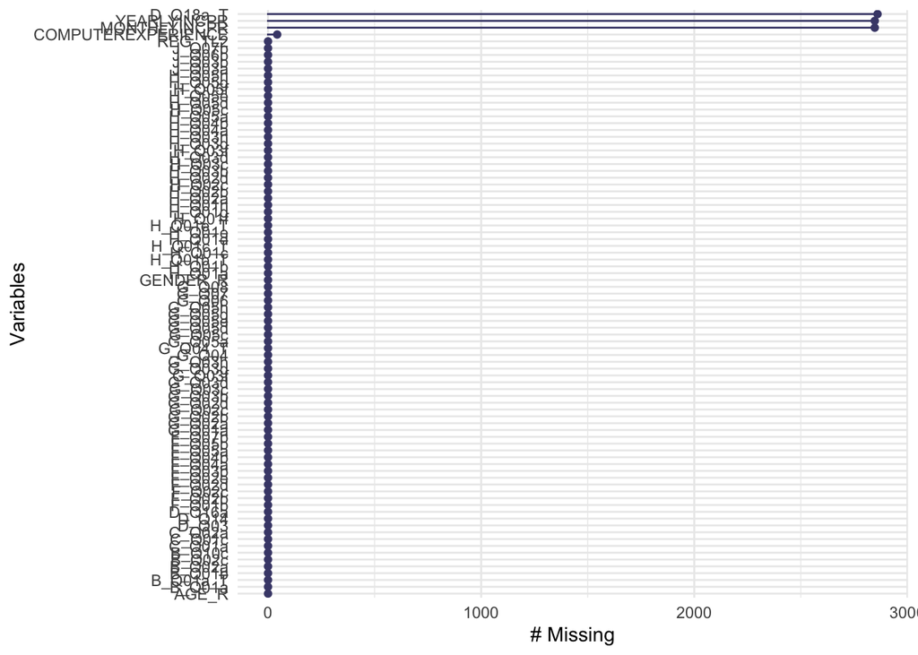

```r
newMexico <- Mexico %>%
  select("AGE_R", "GENDER_R","B_Q01a", "B_Q01a_T", "B_Q02a", "B_Q02c", "B_Q10c", "B_Q01b", "C_Q01a", "C_Q01c", "C_Q02a", "D_Q03", "D_Q14", "D_Q16a", "D_Q18a_T", "F_Q01b","F_Q02b","F_Q02c","F_Q02d","F_Q02e","F_Q03b","F_Q04a","F_Q04b","F_Q05a","F_Q05b","F_Q07b","G_Q01a","G_Q02a","G_Q02b","G_Q02c","G_Q02d","G_Q03b","G_Q03c","G_Q03d","G_Q03f","G_Q03g","G_Q03h", "G_Q04","G_Q04_T", "G_Q05a", "G_Q05c", "G_Q05d", "G_Q05e", "G_Q05g", "G_Q05h", "G_Q06", "G_Q07", "G_Q08", "H_Q01a", "H_Q01b", "H_Q01b_T", "H_Q01c", "H_Q01c_T", "H_Q01d", "H_Q01e", "H_Q01e_T", "H_Q01f", "H_Q01g", "H_Q01h", "H_Q02a", "H_Q02b","H_Q02c", "H_Q02d", "H_Q03b", "H_Q03c", "H_Q03d", "H_Q03f", "H_Q03g", "H_Q03h","H_Q04a", "H_Q04b", "H_Q05a", "H_Q05c", "H_Q05d", "H_Q05e", "H_Q05f", "H_Q05g", "H_Q05h", "J_Q03a", "J_Q03b", "J_Q06b", "J_Q07b","COMPUTEREXPERIENCE", "MONTHLYINCPR","YEARLYINCPR", "REG_TL2")

## Missing variables
##Vsualizarion of missing variables


gg_miss_var(newMexico)
```

```r
table(is.na(newMexico$YEARLYINCPR))
```

```
##
## FALSE  TRUE
##  3459  2847
```

```r
table(is.na(newMexico$MONTHLYINCPR))
```

```
##
## FALSE  TRUE
##  3459  2847
```

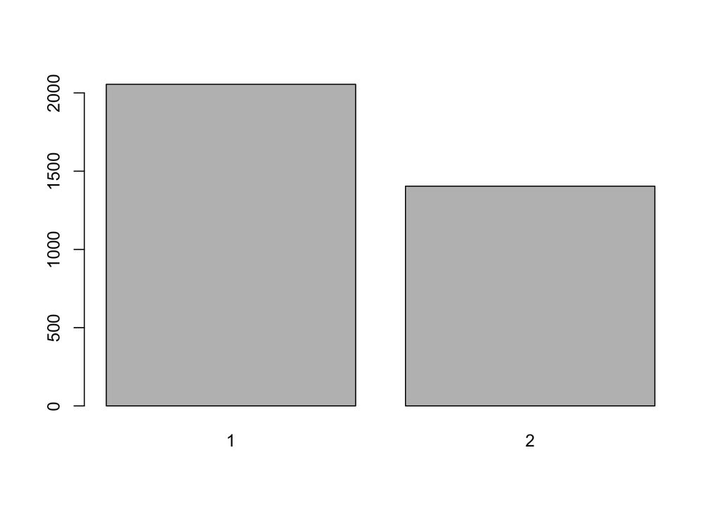

```r
#droping NAs


newMexico1 <- drop_na(newMexico, MONTHLYINCPR)

# Number of women and men


barplot(table(newMexico1$GENDER_R))
```

```r
newMexico1 %>% count(GENDER_R)
```

```
## # A tibble: 2 x 2
##   GENDER_R     n
##      <int> <int>
## 1        1  2055
## 2        2  1404
```

```r
newMexico1 %>% count(B_Q01a)
```

```
## # A tibble: 12 x 2
##    B_Q01a     n
##    <fct>  <int>
##  1 1        295
##  2 11        46
##  3 12       403
##  4 13        37
##  5 14        19
##  6 15         2
##  7 2        623
##  8 3       1215
##  9 5        536
## 10 6        126
## 11 7        156
## 12 D          1
```

```r
newMexico1 %>% count(B_Q01a_T)
```

```
## # A tibble: 5 x 2
##   B_Q01a_T     n
##   <fct>    <int>
## 1 1         2133
## 2 2          818
## 3 3          505
## 4 4            2
## 5 M            1
```

```r
newMexico1 %>% count(B_Q02a)
```

```
## # A tibble: 3 x 2
##   B_Q02a     n
##   <fct>  <int>
## 1 1        263
## 2 2       3195
## 3 R          1
```

```r
newMexico1 %>% count(B_Q02c) #x - 3224 V ESTA 1
```

```
## # A tibble: 11 x 2
##    B_Q02c     n
##    <fct>  <int>
##  1 1         37
##  2 2         19
##  3 3         14
##  4 4         76
##  5 5         21
##  6 6         34
##  7 7          4
##  8 8         22
##  9 9          7
## 10 R          1
## 11 V       3224
```

```r
newMexico1 %>% count(B_Q10c) #x- 3176 V ESTA 2
```

```
## # A tibble: 5 x 2
##   B_Q10c     n
##   <fct>  <int>
## 1 1         41
## 2 2         38
## 3 3         56
## 4 4        148
## 5 V       3176
```

```r
newMexico1 %>% count(B_Q01b) # 2134 v ESTA 3
```

```
## # A tibble: 12 x 2
##    B_Q01b     n
##    <fct>  <int>
##  1 1        177
##  2 2        141
##  3 3         86
##  4 4        406
##  5 5        196
##  6 6        159
##  7 7         20
##  8 8         94
##  9 9         39
## 10 D          4
## 11 R          3
## 12 V       2134
```

```r
newMexico1 %>% count(C_Q01a)
```

```
## # A tibble: 2 x 2
##   C_Q01a     n
##   <fct>  <int>
## 1 1       3356
## 2 2        103
```

```r
newMexico1 %>% count(C_Q01c) # 3459 v ESTA 4
```

```
## # A tibble: 1 x 2
##   C_Q01c     n
##   <fct>  <int>
## 1 V       3459
```

```r
newMexico1 %>% count(C_Q02a) # 3459 v ESTA 5
```

```
## # A tibble: 1 x 2
##   C_Q02a     n
##   <fct>  <int>
## 1 V       3459
```

```r
newMexico1 %>% count(D_Q03) # D 42 - r21
```

```
## # A tibble: 5 x 2
##   D_Q03     n
##   <fct> <int>
## 1 1      2947
## 2 2       415
## 3 3        34
## 4 D        42
## 5 R        21
```

```r
newMexico1 %>% count(D_Q14) #
```

```
## # A tibble: 6 x 2
##   D_Q14     n
##   <fct> <int>
## 1 1      1022
## 2 2      1891
## 3 3       412
## 4 4        99
## 5 5        34
## 6 D         1
```

```r
newMexico1 %>% count(D_Q16a) # V 1008
```

```
## # A tibble: 8 x 2
##   D_Q16a     n
##   <fct>  <int>
## 1 1         58
## 2 2        447
## 3 3       1106
## 4 4        682
## 5 5         97
## 6 6          1
## 7 7         60
## 8 V       1008
```

```r
newMexico1 %>% count(D_Q18a_T) # 13 NA
```

```
## # A tibble: 7 x 2
##   D_Q18a_T     n
##      <int> <int>
## 1        0    79
## 2        1   742
## 3        2   667
## 4        3   692
## 5        4   628
## 6        5   638
## 7       NA    13
```

```r
# ICT skills in Job
newMexico1 %>% count(G_Q04) # experience with computer in job yes no 3 ns
```

```
## # A tibble: 3 x 2
##   G_Q04     n
##   <fct> <int>
## 1 1      1079
## 2 2      2377
## 3 N         3
```

```r
newMexico1%>% count(G_Q04_T) #** 3 N
```

```
## # A tibble: 3 x 2
##   G_Q04_T     n
##   <fct>   <int>
## 1 1        2258
## 2 2        1198
## 3 N           3
```

```r
newMexico1 %>% count(COMPUTEREXPERIENCE) # 3 n
```

```
## # A tibble: 3 x 2
##   COMPUTEREXPERIENCE     n
##                <int> <int>
## 1                  1  2258
## 2                  2  1198
## 3                 NA     3
```

```r
newMexico1 %>% count(G_Q05a) # 2377 v y 3 n
```

```
## # A tibble: 7 x 2
##   G_Q05a     n
##   <fct>  <int>
## 1 1        186
## 2 2         72
## 3 3         50
## 4 4        139
## 5 5        632
## 6 N          3
## 7 V       2377
```

```r
newMexico1 %>% count(D_Q18a_T) # 13 NA
```

```
## # A tibble: 7 x 2
##   D_Q18a_T     n
##      <int> <int>
## 1        0    79
## 2        1   742
## 3        2   667
## 4        3   692
## 5        4   628
## 6        5   638
## 7       NA    13
```

```r
newMexico1 %>% count(F_Q05a) #
```

```
## # A tibble: 7 x 2
##   F_Q05a     n
##   <fct>  <int>
## 1 1        711
## 2 2        673
## 3 3        456
## 4 4        646
## 5 5        970
## 6 D          2
## 7 N          1
```

```r
newMexico1 %>% count(F_Q05b)
```

```
## # A tibble: 7 x 2
##   F_Q05b     n
##   <fct>  <int>
## 1 1       1122
## 2 2        848
## 3 3        501
## 4 4        590
## 5 5        394
## 6 D          3
## 7 N          1
```

```r
newMexico1 %>% count(G_Q04) # experience with computer in job yes no
```

```
## # A tibble: 3 x 2
##   G_Q04     n
##   <fct> <int>
## 1 1      1079
## 2 2      2377
## 3 N         3
```

```r
newMexico1 %>% count(COMPUTEREXPERIENCE) #******
```

```
## # A tibble: 3 x 2
##   COMPUTEREXPERIENCE     n
##                <int> <int>
## 1                  1  2258
## 2                  2  1198
## 3                 NA     3
```

```r
Mexico%>% count(G_Q04_T) #*****
```

```
## # A tibble: 5 x 2
##   G_Q04_T     n
##   <fct>   <int>
## 1 ""         30
## 2 "1"      3895
## 3 "2"      2370
## 4 "N"        10
## 5 "V"         1
```

```r
newMexico1 %>% count(G_Q05a) # 2377 v ESTA 6
```

```
## # A tibble: 7 x 2
##   G_Q05a     n
##   <fct>  <int>
## 1 1        186
## 2 2         72
## 3 3         50
## 4 4        139
## 5 5        632
## 6 N          3
## 7 V       2377
```

```r
newMexico1 %>% count(G_Q05c) # 2377 v ESTA 7
```

```
## # A tibble: 7 x 2
##   G_Q05c     n
##   <fct>  <int>
## 1 1        174
## 2 2         58
## 3 3         43
## 4 4        144
## 5 5        660
## 6 N          3
## 7 V       2377
```

```r
newMexico1 %>% count(G_Q05d) # 2377 ESTA 8
```

```
## # A tibble: 7 x 2
##   G_Q05d     n
##   <fct>  <int>
## 1 1        653
## 2 2         81
## 3 3         68
## 4 4        103
## 5 5        174
## 6 N          3
## 7 V       2377
```

```r
newMexico1 %>% count(G_Q05e) # 2377 ESTA 9
```

```
## # A tibble: 7 x 2
##   G_Q05e     n
##   <fct>  <int>
## 1 1        353
## 2 2         97
## 3 3         69
## 4 4        134
## 5 5        426
## 6 N          3
## 7 V       2377
```

```r
newMexico1 %>% count(G_Q05g) # 2377 ESTA 10
```

```
## # A tibble: 7 x 2
##   G_Q05g     n
##   <fct>  <int>
## 1 1        827
## 2 2         73
## 3 3         28
## 4 4         54
## 5 5         97
## 6 N          3
## 7 V       2377
```

```r
newMexico1 %>% count(G_Q05h) # 2377 ESTA 11
```

```
## # A tibble: 7 x 2
##   G_Q05h     n
##   <fct>  <int>
## 1 1        476
## 2 2         90
## 3 3         69
## 4 4        120
## 5 5        324
## 6 N          3
## 7 V       2377
```

```r
newMexico1 %>% count(G_Q06) # 2377 ESTA 12
```

```
## # A tibble: 6 x 2
##   G_Q06     n
##   <fct> <int>
## 1 1       505
## 2 2       479
## 3 3        92
## 4 N         3
## 5 R         3
## 6 V      2377
```

```r
newMexico1 %>% count(G_Q07) # 2377 ESTA 13
```

```
## # A tibble: 4 x 2
##   G_Q07     n
##   <fct> <int>
## 1 1       937
## 2 2       142
## 3 N         3
## 4 V      2377
```

```r
newMexico1 %>% count(G_Q08) # 2377 ESTA 15
```

```
## # A tibble: 6 x 2
##   G_Q08     n
##   <fct> <int>
## 1 1       225
## 2 2       852
## 3 D         1
## 4 N         3
## 5 R         1
## 6 V      2377
```

```r
newMexico1 %>% count(H_Q04a) # 1074 V experience with compiuter every life
```

```
## # A tibble: 4 x 2
##   H_Q04a     n
##   <fct>  <int>
## 1 1       1179
## 2 2       1198
## 3 N          3
## 4 V       1079
```

```r
newMexico1 %>% count(H_Q04b) # 1198
```

```
## # A tibble: 4 x 2
##   H_Q04b     n
##   <fct>  <int>
## 1 1       1251
## 2 2       1007
## 3 N          3
## 4 V       1198
```

```r
newMexico1 %>% count(H_Q05a) # 2205 ESTA 16
```

```
## # A tibble: 7 x 2
##   H_Q05a     n
##   <fct>  <int>
## 1 1        151
## 2 2        145
## 3 3        107
## 4 4        320
## 5 5        528
## 6 N          3
## 7 V       2205
```

```r
newMexico1 %>% count(H_Q05c) # 2205 ESTA 17
```

```
## # A tibble: 7 x 2
##   H_Q05c     n
##   <fct>  <int>
## 1 1         95
## 2 2        100
## 3 3        104
## 4 4        304
## 5 5        648
## 6 N          3
## 7 V       2205
```

```r
newMexico1 %>% count(H_Q05d) # 2205 ESTA 18
```

```
## # A tibble: 7 x 2
##   H_Q05d     n
##   <fct>  <int>
## 1 1        700
## 2 2        176
## 3 3        143
## 4 4        132
## 5 5        100
## 6 N          3
## 7 V       2205
```

```r
newMexico1 %>% count(H_Q05e) # 2205 ESTA 19
```

```
## # A tibble: 7 x 2
##   H_Q05e     n
##   <fct>  <int>
## 1 1        714
## 2 2        187
## 3 3        118
## 4 4        143
## 5 5         89
## 6 N          3
## 7 V       2205
```

```r
newMexico1 %>% count(H_Q05f) # 2205 ESTA 20
```

```
## # A tibble: 7 x 2
##   H_Q05f     n
##   <fct>  <int>
## 1 1        481
## 2 2        189
## 3 3        148
## 4 4        250
## 5 5        183
## 6 N          3
## 7 V       2205
```

```r
newMexico1 %>% count(H_Q05g) # 2205 ESTA 21
```

```
## # A tibble: 7 x 2
##   H_Q05g     n
##   <fct>  <int>
## 1 1       1045
## 2 2         82
## 3 3         44
## 4 4         47
## 5 5         33
## 6 N          3
## 7 V       2205
```

```r
newMexico1 %>% count(H_Q05h) # 2205 ESTA 22
```

```
## # A tibble: 7 x 2
##   H_Q05h     n
##   <fct>  <int>
## 1 1        341
## 2 2         81
## 3 3         74
## 4 4        179
## 5 5        576
## 6 N          3
## 7 V       2205
```

```r
newMexico1 %>% count(J_Q03a)
```

```
## # A tibble: 3 x 2
##   J_Q03a     n
##   <fct>  <int>
## 1 1       2513
## 2 2        943
## 3 N          3
```

```r
newMexico1 %>% count(J_Q03b) #943
```

```
## # A tibble: 18 x 2
##    J_Q03b     n
##    <fct>  <int>
##  1 1        607
##  2 10         6
##  3 11         1
##  4 12         3
##  5 13         1
##  6 16         1
##  7 19         1
##  8 2        840
##  9 3        598
## 10 4        236
## 11 5         96
## 12 6         61
## 13 7         31
## 14 8         18
## 15 9          9
## 16 N          3
## 17 R          4
## 18 V        943
```

```r
newMexico1 %>% count(J_Q06b)
```

```
## # A tibble: 6 x 2
##   J_Q06b     n
##   <fct>  <int>
## 1 1       2898
## 2 2        257
## 3 3        148
## 4 D        109
## 5 N          3
## 6 R         44
```

```r
newMexico1 %>% count(F_Q01b) #748
```

```
## # A tibble: 8 x 2
##   F_Q01b     n
##   <fct>  <int>
## 1 1        449
## 2 2        525
## 3 3        275
## 4 4        269
## 5 5       1191
## 6 N          1
## 7 R          1
## 8 V        748
```

```r
newMexico1 %>% count(F_Q02b)
```

```
## # A tibble: 7 x 2
##   F_Q02b     n
##   <fct>  <int>
## 1 1       1773
## 2 2        478
## 3 3        249
## 4 4        364
## 5 5        593
## 6 N          1
## 7 R          1
```

```r
newMexico1 %>% count(F_Q02c)
```

```
## # A tibble: 7 x 2
##   F_Q02c     n
##   <fct>  <int>
## 1 1       2429
## 2 2        352
## 3 3        178
## 4 4        215
## 5 5        282
## 6 N          1
## 7 R          2
```

```r
newMexico1 %>% count(F_Q02d)
```

```
## # A tibble: 8 x 2
##   F_Q02d     n
##   <fct>  <int>
## 1 1       1779
## 2 2        147
## 3 3         94
## 4 4        153
## 5 5       1282
## 6 D          1
## 7 N          1
## 8 R          2
```

```r
newMexico1 %>% count(F_Q02e)
```

```
## # A tibble: 7 x 2
##   F_Q02e     n
##   <fct>  <int>
## 1 1       1745
## 2 2        375
## 3 3        206
## 4 4        325
## 5 5        806
## 6 N          1
## 7 R          1
```

```r
newMexico1 %>% count(F_Q03b)
```

```
## # A tibble: 7 x 2
##   F_Q03b     n
##   <fct>  <int>
## 1 1       2360
## 2 2        191
## 3 3        146
## 4 4        257
## 5 5        503
## 6 D          1
## 7 N          1
```

```r
newMexico1 %>% count(F_Q04a)
```

```
## # A tibble: 7 x 2
##   F_Q04a     n
##   <fct>  <int>
## 1 1       1747
## 2 2        196
## 3 3        137
## 4 4        308
## 5 5       1069
## 6 D          1
## 7 N          1
```

```r
newMexico1 %>% count(F_Q04b)
```

```
## # A tibble: 6 x 2
##   F_Q04b     n
##   <fct>  <int>
## 1 1       1762
## 2 2        225
## 3 3        161
## 4 4        307
## 5 5       1003
## 6 N          1
```

```r
newMexico1 %>% count(F_Q05a)
```

```
## # A tibble: 7 x 2
##   F_Q05a     n
##   <fct>  <int>
## 1 1        711
## 2 2        673
## 3 3        456
## 4 4        646
## 5 5        970
## 6 D          2
## 7 N          1
```

```r
newMexico1 %>% count(F_Q05b)
```

```
## # A tibble: 7 x 2
##   F_Q05b     n
##   <fct>  <int>
## 1 1       1122
## 2 2        848
## 3 3        501
## 4 4        590
## 5 5        394
## 6 D          3
## 7 N          1
```

```r
newMexico1 %>% count(G_Q01a)
```

```
## # A tibble: 6 x 2
##   G_Q01a     n
##   <fct>  <int>
## 1 1       1225
## 2 2        338
## 3 3        192
## 4 4        453
## 5 5       1249
## 6 N          2
```

```r
newMexico1 %>% count(G_Q02a)
```

```
## # A tibble: 6 x 2
##   G_Q02a     n
##   <fct>  <int>
## 1 1       1901
## 2 2        181
## 3 3        123
## 4 4        312
## 5 5        940
## 6 N          2
```

```r
newMexico1 %>% count(G_Q02b)
```

```
## # A tibble: 6 x 2
##   G_Q02b     n
##   <fct>  <int>
## 1 1       3231
## 2 2        100
## 3 3         37
## 4 4         45
## 5 5         44
## 6 N          2
```

```r
newMexico1 %>% count(G_Q02c)
```

```
## # A tibble: 6 x 2
##   G_Q02c     n
##   <fct>  <int>
## 1 1       2185
## 2 2        205
## 3 3        159
## 4 4        290
## 5 5        618
## 6 N          2
```

```r
newMexico1 %>% count(G_Q03b)
```

```
## # A tibble: 7 x 2
##   G_Q03b     n
##   <fct>  <int>
## 1 1       1344
## 2 2        277
## 3 3        190
## 4 4        398
## 5 5       1246
## 6 D          1
## 7 N          3
```

```r
newMexico1 %>% count(G_Q03c)
```

```
## # A tibble: 6 x 2
##   G_Q03c     n
##   <fct>  <int>
## 1 1       1843
## 2 2        192
## 3 3        141
## 4 4        349
## 5 5        931
## 6 N          3
```

```r
newMexico1 %>% count(G_Q03d)
```

```
## # A tibble: 6 x 2
##   G_Q03d     n
##   <fct>  <int>
## 1 1       1634
## 2 2        184
## 3 3        148
## 4 4        385
## 5 5       1105
## 6 N          3
```

```r
newMexico1 %>% count(G_Q03f)
```

```
## # A tibble: 6 x 2
##   G_Q03f     n
##   <fct>  <int>
## 1 1       2604
## 2 2        183
## 3 3        160
## 4 4        255
## 5 5        254
## 6 N          3
```

```r
newMexico1 %>% count(G_Q03g)
```

```
## # A tibble: 6 x 2
##   G_Q03g     n
##   <fct>  <int>
## 1 1       2539
## 2 2        138
## 3 3        106
## 4 4        215
## 5 5        458
## 6 N          3
```

```r
newMexico1 %>% count(G_Q03h)
```

```
## # A tibble: 6 x 2
##   G_Q03h     n
##   <fct>  <int>
## 1 1       3050
## 2 2        128
## 3 3         76
## 4 4         87
## 5 5        115
## 6 N          3
```

```r
newMexico1 %>% count(H_Q01a)
```

```
## # A tibble: 6 x 2
##   H_Q01a     n
##   <fct>  <int>
## 1 1       1480
## 2 2        445
## 3 3        262
## 4 4        563
## 5 5        706
## 6 N          3
```

```r
newMexico1 %>% count(H_Q01b)
```

```
## # A tibble: 6 x 2
##   H_Q01b     n
##   <fct>  <int>
## 1 1       1588
## 2 2        314
## 3 3        200
## 4 4        488
## 5 5        866
## 6 N          3
```

```r
newMexico1 %>% count(H_Q01b_T)
```

```
## # A tibble: 5 x 2
##   H_Q01b_T     n
##   <fct>    <int>
## 1 1         1354
## 2 2          200
## 3 3          314
## 4 4         1588
## 5 N            3
```

```r
newMexico1 %>% count(H_Q01d)
```

```
## # A tibble: 6 x 2
##   H_Q01d     n
##   <fct>  <int>
## 1 1       2229
## 2 2        339
## 3 3        235
## 4 4        396
## 5 5        257
## 6 N          3
```

```r
newMexico1 %>% count(H_Q01c)
```

```
## # A tibble: 6 x 2
##   H_Q01c     n
##   <fct>  <int>
## 1 1       1391
## 2 2        402
## 3 3        309
## 4 4        723
## 5 5        631
## 6 N          3
```

```r
newMexico1 %>% count(H_Q01e)
```

```
## # A tibble: 7 x 2
##   H_Q01e     n
##   <fct>  <int>
## 1 1       1933
## 2 2        506
## 3 3        291
## 4 4        415
## 5 5        310
## 6 N          3
## 7 R          1
```

```r
newMexico1 %>% count(H_Q01e_T)
```

```
## # A tibble: 6 x 2
##   H_Q01e_T     n
##   <fct>    <int>
## 1 1          725
## 2 2          291
## 3 3          506
## 4 4         1933
## 5 N            3
## 6 R            1
```

```r
newMexico1 %>% count(H_Q01f)
```

```
## # A tibble: 7 x 2
##   H_Q01f     n
##   <fct>  <int>
## 1 1       2113
## 2 2        447
## 3 3        306
## 4 4        370
## 5 5        219
## 6 N          3
## 7 R          1
```

```r
newMexico1 %>% count(H_Q01g)
```

```
## # A tibble: 6 x 2
##   H_Q01g     n
##   <fct>  <int>
## 1 1       1245
## 2 2        973
## 3 3        591
## 4 4        432
## 5 5        215
## 6 N          3
```

```r
newMexico1 %>% count(H_Q01h)
```

```
## # A tibble: 6 x 2
##   H_Q01h     n
##   <fct>  <int>
## 1 1       2739
## 2 2        257
## 3 3        141
## 4 4        190
## 5 5        129
## 6 N          3
```

```r
newMexico1 %>% count(H_Q02a)
```

```
## # A tibble: 6 x 2
##   H_Q02a     n
##   <fct>  <int>
## 1 1       1703
## 2 2        329
## 3 3        224
## 4 4        487
## 5 5        713
## 6 N          3
```

```r
newMexico1 %>% count(H_Q02b)
```

```
## # A tibble: 6 x 2
##   H_Q02b     n
##   <fct>  <int>
## 1 1       3273
## 2 2         64
## 3 3         39
## 4 4         46
## 5 5         34
## 6 N          3
```

```r
newMexico1 %>% count(H_Q02c)
```

```
## # A tibble: 6 x 2
##   H_Q02c     n
##   <fct>  <int>
## 1 1       2950
## 2 2        159
## 3 3         90
## 4 4        158
## 5 5         99
## 6 N          3
```

```r
newMexico1 %>% count(H_Q02d)
```

```
## # A tibble: 6 x 2
##   H_Q02d     n
##   <fct>  <int>
## 1 1       2853
## 2 2        251
## 3 3        115
## 4 4        131
## 5 5        106
## 6 N          3
```

```r
newMexico1 %>% count(H_Q03b)
```

```
## # A tibble: 6 x 2
##   H_Q03b     n
##   <fct>  <int>
## 1 1        788
## 2 2        353
## 3 3        333
## 4 4        873
## 5 5       1109
## 6 N          3
```

```r
newMexico1 %>% count(H_Q03c)
```

```
## # A tibble: 7 x 2
##   H_Q03c     n
##   <fct>  <int>
## 1 1       1957
## 2 2        302
## 3 3        255
## 4 4        469
## 5 5        471
## 6 D          2
## 7 N          3
```

```r
newMexico1 %>% count(H_Q03d)
```

```
## # A tibble: 6 x 2
##   H_Q03d     n
##   <fct>  <int>
## 1 1       1605
## 2 2        375
## 3 3        310
## 4 4        625
## 5 5        541
## 6 N          3
```

```r
newMexico1 %>% count(H_Q03f)
```

```
## # A tibble: 6 x 2
##   H_Q03f     n
##   <fct>  <int>
## 1 1       2984
## 2 2        172
## 3 3        101
## 4 4        134
## 5 5         65
## 6 N          3
```

```r
newMexico1 %>% count(H_Q03g)
```

```
## # A tibble: 6 x 2
##   H_Q03g     n
##   <fct>  <int>
## 1 1       2752
## 2 2        152
## 3 3        106
## 4 4        191
## 5 5        255
## 6 N          3
```

```r
newMexico1 %>% count(H_Q03h)
```

```
## # A tibble: 6 x 2
##   H_Q03h     n
##   <fct>  <int>
## 1 1       3125
## 2 2        112
## 3 3         62
## 4 4         89
## 5 5         68
## 6 N          3
```

```r
newMexico1 %>% count(REG_TL2)
```

```
## # A tibble: 32 x 2
##    REG_TL2     n
##    <fct>   <int>
##  1 ME01       39
##  2 ME02      145
##  3 ME03       25
##  4 ME04       24
##  5 ME05      100
##  6 ME06       18
##  7 ME07      111
##  8 ME08      143
##  9 ME09      292
## 10 ME10       48
## # … with 22 more rows
```

```r
Mexico %>% count(YEARLYINCPR) #2847
```

```
## # A tibble: 7 x 2
##   YEARLYINCPR     n
##         <int> <int>
## 1           1   521
## 2           2   426
## 3           3   783
## 4           4   702
## 5           5   559
## 6           6   468
## 7          NA  2847
```

```r
Mexico %>% count(EARNMTH) #2847
```

```
## # A tibble: 306 x 2
##    EARNMTH        n
##    <fct>      <int>
##  1 ""            97
##  2 "0"            2
##  3 "1000"         1
##  4 "10000"        5
##  5 "10064.17"     1
##  6 "10183.33"     4
##  7 "10241.83"     1
##  8 "1040"         1
##  9 "10400"       16
## 10 "10500"        1
## # … with 296 more rows
```

```r
Mexico %>% count(EARNMTHPPP) #3t68
```

```
## # A tibble: 306 x 2
##    EARNMTHPPP     n
##    <fct>      <int>
##  1 ""            97
##  2 "0"            2
##  3 "1005.87"      2
##  4 "1011.82"      1
##  5 "103.17"       5
##  6 "1030.63"      1
##  7 "1031.66"    110
##  8 "10316.6"      2
##  9 "1053.32"      1
## 10 "1057.45"      1
## # … with 296 more rows
```

```r
Mexico %>% count(EARNHR)#3758
```

```
## # A tibble: 704 x 2
##    EARNHR      n
##    <fct>   <int>
##  1 ""         97
##  2 "0"         2
##  3 "10"        7
##  4 "10.2"      1
##  5 "10.42"    15
##  6 "10.77"     2
##  7 "10.81"     1
##  8 "10.87"     1
##  9 "10.92"     1
## 10 "10.94"     1
## # … with 694 more rows
```

```r
Mexico %>% count(EARNHRBONUS) # 97 ESPACIOS VACIOS
```

```
## # A tibble: 1,435 x 2
##    EARNHRBONUS     n
##    <fct>       <int>
##  1 ""             97
##  2 "0"             2
##  3 "10"            5
##  4 "10.13"         1
##  5 "10.2"          1
##  6 "10.42"        14
##  7 "10.77"         2
##  8 "10.81"         1
##  9 "10.87"         1
## 10 "10.94"         1
## # … with 1,425 more rows
```

```r
Mexico %>% count(ICTWORK)
```

```
## # A tibble: 628 x 2
##    ICTWORK       n
##    <fct>     <int>
##  1 ""           30
##  2 "0.23097"     3
##  3 "0.254"       7
##  4 "0.33628"     1
##  5 "0.38284"     1
##  6 "0.42779"     5
##  7 "0.4318"      1
##  8 "0.45167"     2
##  9 "0.47435"     3
## 10 "0.49024"     1
## # … with 618 more rows
```

```r
Mexico %>% count(EARNHRBONUSPPP) # 97 vacios usd
```

```
## # A tibble: 949 x 2
##    EARNHRBONUSPPP     n
##    <fct>          <int>
##  1 ""                97
##  2 "0"                2
##  3 "0.26"             1
##  4 "0.28"             1
##  5 "0.34"             1
##  6 "0.44"             1
##  7 "0.53"             1
##  8 "0.57"             1
##  9 "0.65"             1
## 10 "0.66"             1
## # … with 939 more rows
```

```r
Mexico %>% count(EARNFLAG) #2548
```

```
## # A tibble: 4 x 2
##   EARNFLAG     n
##   <fct>    <int>
## 1 1         3402
## 2 2           57
## 3 N          299
## 4 V         2548
```

**Adaptation of the dataset**

Since there are non numeric factor in our dataset such as V, N and R we had to convert them in NAs in order to work with thw variables afterwards.

```r
#Gender

newMexico1$GENDER_Rn[newMexico1$GENDER_R == "1"] = 0
newMexico1$GENDER_Rn[newMexico1$GENDER_R == "2"] = 1


#B_Q01a
newMexico1$B_Q01an[newMexico1$B_Q01a == "D"] = NA
newMexico1$B_Q01an[newMexico1$B_Q01a == "1"] = 1
newMexico1$B_Q01an[newMexico1$B_Q01a == "2"] = 2
newMexico1$B_Q01an[newMexico1$B_Q01a == "5"] = 5
newMexico1$B_Q01an[newMexico1$B_Q01a == "6"] = 6
newMexico1$B_Q01an[newMexico1$B_Q01a == "7"] = 7
newMexico1$B_Q01an[newMexico1$B_Q01a == "11"] = 11
newMexico1$B_Q01an[newMexico1$B_Q01a == "12"] = 12
newMexico1$B_Q01an[newMexico1$B_Q01a == "13"] = 13
newMexico1$B_Q01an[newMexico1$B_Q01a == "14"] = 14
newMexico1$B_Q01an[newMexico1$B_Q01a == "15"] = 15

#B_Q01a_T

newMexico1$B_Q01a_Tn[newMexico1$B_Q01a_T == "M"] = NA
newMexico1$B_Q01a_Tn[newMexico1$B_Q01a_T == "1"] = 1
newMexico1$B_Q01a_Tn[newMexico1$B_Q01a_T == "2"] = 2
newMexico1$B_Q01a_Tn[newMexico1$B_Q01a_T == "3"] = 3
newMexico1$B_Q01a_Tn[newMexico1$B_Q01a_T == "4"] = 4

#B_Q02a

newMexico1$B_Q02an[newMexico1$B_Q02a == "R"] = NA
newMexico1$B_Q02an[newMexico1$B_Q02a == "1"] = 0
newMexico1$B_Q02an[newMexico1$B_Q02a== "2"] = 1

#B_Q02c
newMexico1$B_Q02cn[newMexico1$B_Q02c == "V"] = NA
newMexico1$B_Q02cn[newMexico1$B_Q02c == "1"] = 1
newMexico1$B_Q02cn[newMexico1$B_Q02c == "2"] = 2
newMexico1$B_Q02cn[newMexico1$B_Q02c == "3"] = 3
newMexico1$B_Q02cn[newMexico1$B_Q02c == "4"] = 4
newMexico1$B_Q02cn[newMexico1$B_Q02c == "5"] = 5
newMexico1$B_Q02cn[newMexico1$B_Q02c == "6"] = 6
newMexico1$B_Q02cn[newMexico1$B_Q02c == "7"] = 7
newMexico1$B_Q02cn[newMexico1$B_Q02c == "8"] = 8
newMexico1$B_Q02cn[newMexico1$B_Q02c == "9"] = 9
newMexico1$B_Q02cn[newMexico1$B_Q02c == "R"] = NA

#B_Q10c

newMexico1$B_Q10cn[newMexico1$B_Q10c == "V"] = NA
newMexico1$B_Q10cn[newMexico1$B_Q10c == "1"] = 1
newMexico1$B_Q10cn[newMexico1$B_Q10c == "2"] = 2
newMexico1$B_Q10cn[newMexico1$B_Q10c == "3"] = 3
newMexico1$B_Q10cn[newMexico1$B_Q10c == "4"] = 4

#B_Q01b

newMexico1$B_Q01bn[newMexico1$B_Q01b == "V"] = NA
newMexico1$B_Q01bn[newMexico1$B_Q01b == "D"] = NA
newMexico1$B_Q01bn[newMexico1$B_Q01b == "R"] = NA
newMexico1$B_Q01bn[newMexico1$B_Q01b == "1"] = 1
newMexico1$B_Q01bn[newMexico1$B_Q01b == "2"] = 2
newMexico1$B_Q01bn[newMexico1$B_Q01b == "3"] = 3
newMexico1$B_Q01bn[newMexico1$B_Q01b == "4"] = 4
newMexico1$B_Q01bn[newMexico1$B_Q01b == "5"] = 5
newMexico1$B_Q01bn[newMexico1$B_Q01b == "6"] = 6
newMexico1$B_Q01bn[newMexico1$B_Q01b == "7"] = 7
newMexico1$B_Q01bn[newMexico1$B_Q01b == "8"] = 8
newMexico1$B_Q01bn[newMexico1$B_Q01b == "9"] = 9

#C_Q01a
newMexico1$C_Q01an[newMexico1$C_Q01a == "N"] = NA

# C_Q01c
newMexico1$C_Q01cn[newMexico1$C_Q01c == "V"] = NA

#C_Q02a

newMexico1$C_Q02an[newMexico1$C_Q02a == "V"] = NA

#D_Q03

newMexico1$D_Q03n[newMexico1$D_Q03 == "R"] = NA
newMexico1$D_Q03n[newMexico1$D_Q03 == "D"] = NA
newMexico1$D_Q03n[newMexico1$D_Q03 == "1"] = 1
newMexico1$D_Q03n[newMexico1$D_Q03 == "2"] = 2
newMexico1$D_Q03n[newMexico1$D_Q03 == "3"] = 3

#D_Q14

newMexico1$D_Q14n[newMexico1$D_Q14 == "D"] = NA
newMexico1$D_Q14n[newMexico1$D_Q14 == "1"] = 1
newMexico1$D_Q14n[newMexico1$D_Q14 == "2"] = 2
newMexico1$D_Q14n[newMexico1$D_Q14 == "3"] = 3
newMexico1$D_Q14n[newMexico1$D_Q14 == "4"] = 4
newMexico1$D_Q14n[newMexico1$D_Q14 == "5"] = 5

#D_Q16a

newMexico1$D_Q16an[newMexico1$D_Q16a == "V"] = NA
newMexico1$D_Q16an[newMexico1$D_Q16a == "1"] = 1
newMexico1$D_Q16an[newMexico1$D_Q16a == "2"] = 2
newMexico1$D_Q16an[newMexico1$D_Q16a == "3"] = 3
newMexico1$D_Q16an[newMexico1$D_Q16a == "4"] = 4
newMexico1$D_Q16an[newMexico1$D_Q16a == "5"] = 5
newMexico1$D_Q16an[newMexico1$D_Q16a == "6"] = 6
newMexico1$D_Q16an[newMexico1$D_Q16a == "7"] = 7

#F_Q01b

newMexico1$F_Q01bn[newMexico1$F_Q01b== "1"] = 1
newMexico1$F_Q01bn[newMexico1$F_Q01b== "2"] = 2
newMexico1$F_Q01bn[newMexico1$F_Q01b== "3"] = 3
newMexico1$F_Q01bn[newMexico1$F_Q01b== "4"] = 4
newMexico1$F_Q01bn[newMexico1$F_Q01b== "5"] = 5
newMexico1$F_Q01bn[newMexico1$F_Q01b== "N"] = NA
newMexico1$F_Q01bn[newMexico1$F_Q01b== "R"] = NA
newMexico1$F_Q01bn[newMexico1$F_Q01b== "V"] = NA

#F_Q02b

newMexico1$F_Q02bn[newMexico1$F_Q02b== "1"] = 1
newMexico1$F_Q02bn[newMexico1$F_Q02b== "2"] = 2
newMexico1$F_Q02bn[newMexico1$F_Q02b== "3"] = 3
newMexico1$F_Q02bn[newMexico1$F_Q02b== "4"] = 4
newMexico1$F_Q02bn[newMexico1$F_Q02b== "5"] = 5
newMexico1$F_Q02bn[newMexico1$F_Q02b== "N"] = NA
newMexico1$F_Q02bn[newMexico1$F_Q02b== "R"] = NA

#F_Q02c

newMexico1$F_Q02cn[newMexico1$F_Q02c== "1"] = 1
newMexico1$F_Q02cn[newMexico1$F_Q02c== "2"] = 2
newMexico1$F_Q02cn[newMexico1$F_Q02c== "3"] = 3
newMexico1$F_Q02cn[newMexico1$F_Q02c== "4"] = 4
newMexico1$F_Q02cn[newMexico1$F_Q02c== "5"] = 5
newMexico1$F_Q02cn[newMexico1$F_Q02c== "N"] = NA
newMexico1$F_Q02cn[newMexico1$F_Q02c== "R"] = NA

#F_Q02d

newMexico1$F_Q02dn[newMexico1$F_Q02d== "1"] = 1
newMexico1$F_Q02dn[newMexico1$F_Q02d== "2"] = 2
newMexico1$F_Q02dn[newMexico1$F_Q02d== "3"] = 3
newMexico1$F_Q02dn[newMexico1$F_Q02d== "4"] = 4
newMexico1$F_Q02dn[newMexico1$F_Q02d== "5"] = 5
newMexico1$F_Q02dn[newMexico1$F_Q02d== "D"] = NA
newMexico1$F_Q02dn[newMexico1$F_Q02d== "N"] = NA
newMexico1$F_Q02dn[newMexico1$F_Q02d== "R"] = NA

#F_Q02e

newMexico1$F_Q02en[newMexico1$F_Q02e== "1"] = 1
newMexico1$F_Q02en[newMexico1$F_Q02e== "2"] = 2
newMexico1$F_Q02en[newMexico1$F_Q02e== "3"] = 3
newMexico1$F_Q02en[newMexico1$F_Q02e== "4"] = 4
newMexico1$F_Q02en[newMexico1$F_Q02e== "5"] = 5
newMexico1$F_Q02en[newMexico1$F_Q02e== "N"] = NA
newMexico1$F_Q02en[newMexico1$F_Q02e== "R"] = NA

#F_Q03b

newMexico1$F_Q03bn[newMexico1$F_Q03b== "1"] = 1
newMexico1$F_Q03bn[newMexico1$F_Q03b== "2"] = 2
newMexico1$F_Q03bn[newMexico1$F_Q03b== "3"] = 3
newMexico1$F_Q03bn[newMexico1$F_Q03b== "4"] = 4
newMexico1$F_Q03bn[newMexico1$F_Q03b== "5"] = 5
newMexico1$F_Q03bn[newMexico1$F_Q03b== "D"] = NA
newMexico1$F_Q03bn[newMexico1$F_Q03b== "N"] = NA

#F_Q04a

newMexico1$F_Q04an[newMexico1$F_Q04a== "1"] = 1
newMexico1$F_Q04an[newMexico1$F_Q04a== "2"] = 2
newMexico1$F_Q04an[newMexico1$F_Q04a== "3"] = 3
newMexico1$F_Q04an[newMexico1$F_Q04a== "4"] = 4
newMexico1$F_Q04an[newMexico1$F_Q04a== "5"] = 5
newMexico1$F_Q04an[newMexico1$F_Q04a== "D"] = NA
newMexico1$F_Q04an[newMexico1$F_Q04a== "N"] = NA
```

```r
#F_Q04b

newMexico1$F_Q04bn[newMexico1$F_Q04b== "1"] = 1
newMexico1$F_Q04bn[newMexico1$F_Q04b== "2"] = 2
newMexico1$F_Q04bn[newMexico1$F_Q04b== "3"] = 3
newMexico1$F_Q04bn[newMexico1$F_Q04b== "4"] = 4
newMexico1$F_Q04bn[newMexico1$F_Q04b== "5"] = 5
newMexico1$F_Q04bn[newMexico1$F_Q04b== "N"] = NA

#F_Q05a

newMexico1$F_Q05an[newMexico1$F_Q05a == "D"] = NA
newMexico1$F_Q05an[newMexico1$F_Q05a == "N"] = NA
newMexico1$F_Q05an[newMexico1$F_Q05a == "1"] = 1
newMexico1$F_Q05an[newMexico1$F_Q05a == "2"] = 2
newMexico1$F_Q05an[newMexico1$F_Q05a == "3"] = 3
newMexico1$F_Q05an[newMexico1$F_Q05a == "4"] = 4
newMexico1$F_Q05an[newMexico1$F_Q05a == "5"] = 5

#F_Q05b

newMexico1$F_Q05bn[newMexico1$F_Q05b == "D"] = NA
newMexico1$F_Q05bn[newMexico1$F_Q05b == "N"] = NA
newMexico1$F_Q05bn[newMexico1$F_Q05b == "1"] = 1
newMexico1$F_Q05bn[newMexico1$F_Q05b == "2"] = 2
newMexico1$F_Q05bn[newMexico1$F_Q05b == "3"] = 3
newMexico1$F_Q05bn[newMexico1$F_Q05b == "4"] = 4
newMexico1$F_Q05bn[newMexico1$F_Q05b == "5"] = 5

#F_Q07b

newMexico1$F_Q07bn[newMexico1$F_Q07b == "D"] = NA
newMexico1$F_Q07bn[newMexico1$F_Q07b == "N"] = NA
newMexico1$F_Q07bn[newMexico1$F_Q07b == "1"] = 0
newMexico1$F_Q07bn[newMexico1$F_Q07b == "2"] = 1

# G_Q01a

newMexico1$G_Q01an[newMexico1$G_Q01a == "N"] = NA
newMexico1$G_Q01an[newMexico1$G_Q01a == "1"] = 1
newMexico1$G_Q01an[newMexico1$G_Q01a == "2"] = 2
newMexico1$G_Q01an[newMexico1$G_Q01a == "3"] = 3
newMexico1$G_Q01an[newMexico1$G_Q01a == "4"] = 4
newMexico1$G_Q01an[newMexico1$G_Q01a == "5"] = 5

# G_Q02a

newMexico1$G_Q02an[newMexico1$G_Q02a == "N"] = NA
newMexico1$G_Q02an[newMexico1$G_Q02a == "1"] = 1
newMexico1$G_Q02an[newMexico1$G_Q02a == "2"] = 2
newMexico1$G_Q02an[newMexico1$G_Q02a == "3"] = 3
newMexico1$G_Q02an[newMexico1$G_Q02a == "4"] = 4
newMexico1$G_Q02an[newMexico1$G_Q02a == "5"] = 5

# G_Q02b

newMexico1$G_Q02bn[newMexico1$G_Q02b== "1"] = 1
newMexico1$G_Q02bn[newMexico1$G_Q02b== "2"] = 2
newMexico1$G_Q02bn[newMexico1$G_Q02b== "3"] = 3
newMexico1$G_Q02bn[newMexico1$G_Q02b== "4"] = 4
newMexico1$G_Q02bn[newMexico1$G_Q02b== "5"] = 5
newMexico1$G_Q02bn[newMexico1$G_Q02b== "N"] = NA

# G_Q02c

newMexico1$G_Q02cn[newMexico1$G_Q02c == "N"] = NA
newMexico1$G_Q02cn[newMexico1$G_Q02c == "1"] = 1
newMexico1$G_Q02cn[newMexico1$G_Q02c == "2"] = 2
newMexico1$G_Q02cn[newMexico1$G_Q02c == "3"] = 3
newMexico1$G_Q02cn[newMexico1$G_Q02c == "4"] = 4
newMexico1$G_Q02cn[newMexico1$G_Q02c == "5"] = 5

# G_Q02d

newMexico1$G_Q02dn[newMexico1$G_Q02d == "N"] = NA
newMexico1$G_Q02dn[newMexico1$G_Q02d == "1"] = 1
newMexico1$G_Q02dn[newMexico1$G_Q02d == "2"] = 2
newMexico1$G_Q02dn[newMexico1$G_Q02d == "3"] = 3
newMexico1$G_Q02dn[newMexico1$G_Q02d == "4"] = 4
newMexico1$G_Q02dn[newMexico1$G_Q02d == "5"] = 5

# G_Q03b

newMexico1$G_Q03bn[newMexico1$G_Q03b == "D"] = NA
newMexico1$G_Q03bn[newMexico1$G_Q03b == "N"] = NA
newMexico1$G_Q03bn[newMexico1$G_Q03b == "1"] = 1
newMexico1$G_Q03bn[newMexico1$G_Q03b == "2"] = 2
newMexico1$G_Q03bn[newMexico1$G_Q03b == "3"] = 3
newMexico1$G_Q03bn[newMexico1$G_Q03b == "4"] = 4
newMexico1$G_Q03bn[newMexico1$G_Q03b == "5"] = 5

# G_Q03c

newMexico1$G_Q03cn[newMexico1$G_Q03c == "N"] = NA
newMexico1$G_Q03cn[newMexico1$G_Q03c == "1"] = 1
newMexico1$G_Q03cn[newMexico1$G_Q03c == "2"] = 2
newMexico1$G_Q03cn[newMexico1$G_Q03c == "3"] = 3
newMexico1$G_Q03cn[newMexico1$G_Q03c == "4"] = 4
newMexico1$G_Q03cn[newMexico1$G_Q03c == "5"] = 5

# G_Q03d

newMexico1$G_Q03dn[newMexico1$G_Q03d == "N"] = NA
newMexico1$G_Q03dn[newMexico1$G_Q03d == "1"] = 1
newMexico1$G_Q03dn[newMexico1$G_Q03d == "2"] = 2
newMexico1$G_Q03dn[newMexico1$G_Q03d == "3"] = 3
newMexico1$G_Q03dn[newMexico1$G_Q03d == "4"] = 4
newMexico1$G_Q03dn[newMexico1$G_Q03d == "5"] = 5

# G_Q03f

newMexico1$G_Q03fn[newMexico1$G_Q03f == "N"] = NA
newMexico1$G_Q03fn[newMexico1$G_Q03f == "1"] = 1
newMexico1$G_Q03fn[newMexico1$G_Q03f == "2"] = 2
newMexico1$G_Q03fn[newMexico1$G_Q03f == "3"] = 3
newMexico1$G_Q03fn[newMexico1$G_Q03f == "4"] = 4
newMexico1$G_Q03fn[newMexico1$G_Q03f == "5"] = 5

# G_Q03g

newMexico1$G_Q03gn[newMexico1$G_Q03g == "N"] = NA
newMexico1$G_Q03gn[newMexico1$G_Q03g == "1"] = 1
newMexico1$G_Q03gn[newMexico1$G_Q03g == "2"] = 2
newMexico1$G_Q03gn[newMexico1$G_Q03g == "3"] = 3
newMexico1$G_Q03gn[newMexico1$G_Q03g == "4"] = 4
newMexico1$G_Q03gn[newMexico1$G_Q03g == "5"] = 5

# G_Q03h

newMexico1$G_Q03hn[newMexico1$G_Q03h == "N"] = NA
newMexico1$G_Q03hn[newMexico1$G_Q03h == "1"] = 1
newMexico1$G_Q03hn[newMexico1$G_Q03h == "2"] = 2
newMexico1$G_Q03hn[newMexico1$G_Q03h == "3"] = 3
newMexico1$G_Q03hn[newMexico1$G_Q03h == "4"] = 4
newMexico1$G_Q03hn[newMexico1$G_Q03h == "5"] = 5

# G_Q04

newMexico1$G_Q04n[newMexico1$G_Q04 == "N"] = NA
newMexico1$G_Q04n[newMexico1$G_Q04 == "1"] = 0
newMexico1$G_Q04n[newMexico1$G_Q04 == "2"] = 1

# G_Q04_T

newMexico1$G_Q04_Tn[newMexico1$G_Q04_T == "N"] = NA
newMexico1$G_Q04_Tn[newMexico1$G_Q04_T == "1"] = 0
newMexico1$G_Q04_Tn[newMexico1$G_Q04_T == "2"] = 1

# G_Q05a

newMexico1$G_Q05an[newMexico1$G_Q05a == "V"] = NA
newMexico1$G_Q05an[newMexico1$G_Q05a == "N"] = NA
newMexico1$G_Q05an[newMexico1$G_Q05a == "1"] = 1
newMexico1$G_Q05an[newMexico1$G_Q05a == "2"] = 2
newMexico1$G_Q05an[newMexico1$G_Q05a == "3"] = 3
newMexico1$G_Q05an[newMexico1$G_Q05a == "4"] = 4
newMexico1$G_Q05an[newMexico1$G_Q05a == "5"] = 5

# G_Q05c

newMexico1$G_Q05cn[newMexico1$G_Q05c == "V"] = NA
newMexico1$G_Q05cn[newMexico1$G_Q05c == "N"] = NA
newMexico1$G_Q05cn[newMexico1$G_Q05c == "1"] = 1
newMexico1$G_Q05cn[newMexico1$G_Q05c == "2"] = 2
newMexico1$G_Q05cn[newMexico1$G_Q05c == "3"] = 3
newMexico1$G_Q05cn[newMexico1$G_Q05c == "4"] = 4
newMexico1$G_Q05cn[newMexico1$G_Q05c == "5"] = 5

#G_Q05d
newMexico1$G_Q05dn[newMexico1$G_Q05d == "V"] = NA
newMexico1$G_Q05dn[newMexico1$G_Q05d == "N"] = NA
newMexico1$G_Q05dn[newMexico1$G_Q05d == "1"] = 1
newMexico1$G_Q05dn[newMexico1$G_Q05d == "2"] = 2
newMexico1$G_Q05dn[newMexico1$G_Q05d == "3"] = 3
newMexico1$G_Q05dn[newMexico1$G_Q05d == "4"] = 4
newMexico1$G_Q05dn[newMexico1$G_Q05d == "5"] = 5
```

```r
#G_Q05e

newMexico1$G_Q05en[newMexico1$G_Q05e == "V"] = NA
newMexico1$G_Q05en[newMexico1$G_Q05e == "N"] = NA
newMexico1$G_Q05en[newMexico1$G_Q05e == "1"] = 1
newMexico1$G_Q05en[newMexico1$G_Q05e == "2"] = 2
newMexico1$G_Q05en[newMexico1$G_Q05e == "3"] = 3
newMexico1$G_Q05en[newMexico1$G_Q05e == "4"] = 4
newMexico1$G_Q05en[newMexico1$G_Q05e == "5"] = 5

#G_Q05g

newMexico1$G_Q05gn[newMexico1$G_Q05g == "V"] = NA
newMexico1$G_Q05gn[newMexico1$G_Q05g == "N"] = NA
newMexico1$G_Q05gn[newMexico1$G_Q05g == "1"] = 1
newMexico1$G_Q05gn[newMexico1$G_Q05g == "2"] = 2
newMexico1$G_Q05gn[newMexico1$G_Q05g == "3"] = 3
newMexico1$G_Q05gn[newMexico1$G_Q05g == "4"] = 4
newMexico1$G_Q05gn[newMexico1$G_Q05g == "5"] = 5

#G_Q05h

newMexico1$G_Q05hn[newMexico1$G_Q05h == "V"] =NA
newMexico1$G_Q05hn[newMexico1$G_Q05h == "N"] =NA
newMexico1$G_Q05hn[newMexico1$G_Q05h == "1"] =1
newMexico1$G_Q05hn[newMexico1$G_Q05h == "2"] =2
newMexico1$G_Q05hn[newMexico1$G_Q05h == "3"] =3
newMexico1$G_Q05hn[newMexico1$G_Q05h == "4"] =4
newMexico1$G_Q05hn[newMexico1$G_Q05h == "5"] =5


#G_Q06

newMexico1$G_Q06n[newMexico1$G_Q06 == "V"] =NA
newMexico1$G_Q06n[newMexico1$G_Q06 == "N"] =NA
newMexico1$G_Q06n[newMexico1$G_Q06 == "R"] =NA
newMexico1$G_Q06n[newMexico1$G_Q06 == "1"] =1
newMexico1$G_Q06n[newMexico1$G_Q06 == "2"] =2
newMexico1$G_Q06n[newMexico1$G_Q06 == "3"] =3
newMexico1$G_Q06n[newMexico1$G_Q06 == "4"] =4
newMexico1$G_Q06n[newMexico1$G_Q06 == "5"] =5

#G_Q07

newMexico1$G_Q07n[newMexico1$G_Q07 == "V"] =NA
newMexico1$G_Q07n[newMexico1$G_Q07 == "N"] =NA
newMexico1$G_Q07n[newMexico1$G_Q07 == "1"] =0
newMexico1$G_Q07n[newMexico1$G_Q07 == "2"] =1

#G_Q08

newMexico1$G_Q08n[newMexico1$G_Q08 == "V"] =NA
newMexico1$G_Q08n[newMexico1$G_Q08 == "N"] =NA
newMexico1$G_Q08n[newMexico1$G_Q08 == "D"] =NA
newMexico1$G_Q08n[newMexico1$G_Q08 == "R"] =NA
newMexico1$G_Q08n[newMexico1$G_Q08 == "1"] =0
newMexico1$G_Q08n[newMexico1$G_Q08 == "2"] =1

#H_q01a

newMexico1$H_Q01an[newMexico1$H_Q01a == "N"] =NA
newMexico1$H_Q01an[newMexico1$H_Q01a == "1"] =1
newMexico1$H_Q01an[newMexico1$H_Q01a == "2"] =2
newMexico1$H_Q01an[newMexico1$H_Q01a == "3"] =3
newMexico1$H_Q01an[newMexico1$H_Q01a == "4"] =4
newMexico1$H_Q01an[newMexico1$H_Q01a == "5"] =5

#H_q01b

newMexico1$H_Q01bn[newMexico1$H_Q01b == "N"] =NA
newMexico1$H_Q01bn[newMexico1$H_Q01b == "1"] =1
newMexico1$H_Q01bn[newMexico1$H_Q01b == "2"] =2
newMexico1$H_Q01bn[newMexico1$H_Q01b == "3"] =3
newMexico1$H_Q01bn[newMexico1$H_Q01b == "4"] =4
newMexico1$H_Q01bn[newMexico1$H_Q01b == "5"] =5

#H_q01b_T

newMexico1$H_Q01b_Tn[newMexico1$H_Q01b_T == "N"] =NA
newMexico1$H_Q01b_Tn[newMexico1$H_Q01b_T == "1"] =1
newMexico1$H_Q01b_Tn[newMexico1$H_Q01b_T == "2"] =2
newMexico1$H_Q01b_Tn[newMexico1$H_Q01b_T == "3"] =3
newMexico1$H_Q01b_Tn[newMexico1$H_Q01b_T == "4"] =4
newMexico1$H_Q01b_Tn[newMexico1$H_Q01b_T == "5"] =5

#H_q01c

newMexico1$H_Q01cn[newMexico1$H_Q01c == "N"] =NA
newMexico1$H_Q01cn[newMexico1$H_Q01c == "1"] =1
newMexico1$H_Q01cn[newMexico1$H_Q01c == "2"] =2
newMexico1$H_Q01cn[newMexico1$H_Q01c == "3"] =3
newMexico1$H_Q01cn[newMexico1$H_Q01c == "4"] =4
newMexico1$H_Q01cn[newMexico1$H_Q01c == "5"] =5

#H_q01c_T

newMexico1$H_Q01c_Tn[newMexico1$H_Q01c_T == "N"] =NA
newMexico1$H_Q01c_Tn[newMexico1$H_Q01c_T == "1"] =1
newMexico1$H_Q01c_Tn[newMexico1$H_Q01c_T == "2"] =2
newMexico1$H_Q01c_Tn[newMexico1$H_Q01c_T == "3"] =3
newMexico1$H_Q01c_Tn[newMexico1$H_Q01c_T == "4"] =4
newMexico1$H_Q01c_Tn[newMexico1$H_Q01c_T == "5"] =5

#H_q01d

newMexico1$H_Q01dn[newMexico1$H_Q01d == "N"] =NA
newMexico1$H_Q01dn[newMexico1$H_Q01d == "1"] =1
newMexico1$H_Q01dn[newMexico1$H_Q01d == "2"] =2
newMexico1$H_Q01dn[newMexico1$H_Q01d == "3"] =3
newMexico1$H_Q01dn[newMexico1$H_Q01d == "4"] =4
newMexico1$H_Q01dn[newMexico1$H_Q01d == "5"] =5

#H_q01e

newMexico1$H_Q01en[newMexico1$H_Q01e == "N"] =NA
newMexico1$H_Q01en[newMexico1$H_Q01e == "R"] =NA
newMexico1$H_Q01en[newMexico1$H_Q01e == "1"] =1
newMexico1$H_Q01en[newMexico1$H_Q01e == "2"] =2
newMexico1$H_Q01en[newMexico1$H_Q01e == "3"] =3
newMexico1$H_Q01en[newMexico1$H_Q01e == "4"] =4
newMexico1$H_Q01en[newMexico1$H_Q01e == "5"] =5

#H_q01e_T

newMexico1$H_Q01e_Tn[newMexico1$H_Q01e_T == "N"] =NA
newMexico1$H_Q01e_Tn[newMexico1$H_Q01e_T == "R"] =NA
newMexico1$H_Q01e_Tn[newMexico1$H_Q01e_T == "1"] =1
newMexico1$H_Q01e_Tn[newMexico1$H_Q01e_T == "2"] =2
newMexico1$H_Q01e_Tn[newMexico1$H_Q01e_T == "3"] =3
newMexico1$H_Q01e_Tn[newMexico1$H_Q01e_T == "4"] =4
newMexico1$H_Q01e_Tn[newMexico1$H_Q01e_T == "5"] =5

#H_q01f

newMexico1$H_Q01fn[newMexico1$H_Q01f == "N"] =NA
newMexico1$H_Q01fn[newMexico1$H_Q01f == "R"] =NA
newMexico1$H_Q01fn[newMexico1$H_Q01f == "1"] =1
newMexico1$H_Q01fn[newMexico1$H_Q01f == "2"] =2
newMexico1$H_Q01fn[newMexico1$H_Q01f == "3"] =3
newMexico1$H_Q01fn[newMexico1$H_Q01f == "4"] =4
newMexico1$H_Q01fn[newMexico1$H_Q01f == "5"] =5

#H_q01g

newMexico1$H_Q01gn[newMexico1$H_Q01g == "N"] =NA
newMexico1$H_Q01gn[newMexico1$H_Q01g == "1"] =1
newMexico1$H_Q01gn[newMexico1$H_Q01g == "2"] =2
newMexico1$H_Q01gn[newMexico1$H_Q01g == "3"] =3
newMexico1$H_Q01gn[newMexico1$H_Q01g == "4"] =4
newMexico1$H_Q01gn[newMexico1$H_Q01g == "5"] =5

#H_q01h

newMexico1$H_Q01hn[newMexico1$H_Q01h== "1"] = 1
newMexico1$H_Q01hn[newMexico1$H_Q01h== "2"] = 2
newMexico1$H_Q01hn[newMexico1$H_Q01h== "3"] = 3
newMexico1$H_Q01hn[newMexico1$H_Q01h== "4"] = 4
newMexico1$H_Q01hn[newMexico1$H_Q01h== "5"] = 5
newMexico1$H_Q01hn[newMexico1$H_Q01h== "N"] = NA

#H_q02a

newMexico1$H_Q02an[newMexico1$H_Q02a== "1"] = 1
newMexico1$H_Q02an[newMexico1$H_Q02a== "2"] = 2
newMexico1$H_Q02an[newMexico1$H_Q02a== "3"] = 3
newMexico1$H_Q02an[newMexico1$H_Q02a== "4"] = 4
newMexico1$H_Q02an[newMexico1$H_Q02a== "5"] = 5
newMexico1$H_Q02an[newMexico1$H_Q02a== "N"] = NA

#H_q02b

newMexico1$H_Q02bn[newMexico1$H_Q02b== "1"] = 1
newMexico1$H_Q02bn[newMexico1$H_Q02b== "2"] = 2
newMexico1$H_Q02bn[newMexico1$H_Q02b== "3"] = 3
newMexico1$H_Q02bn[newMexico1$H_Q02b== "4"] = 4
newMexico1$H_Q02bn[newMexico1$H_Q02b== "5"] = 5
newMexico1$H_Q02bn[newMexico1$H_Q02b== "N"] = NA
```

```r
#H_q02c

newMexico1$H_Q02cn[newMexico1$H_Q02c== "1"] = 1
newMexico1$H_Q02cn[newMexico1$H_Q02c== "2"] = 2
newMexico1$H_Q02cn[newMexico1$H_Q02c== "3"] = 3
newMexico1$H_Q02cn[newMexico1$H_Q02c== "4"] = 4
newMexico1$H_Q02cn[newMexico1$H_Q02c== "5"] = 5
newMexico1$H_Q02cn[newMexico1$H_Q02c== "N"] = NA

#H_q02d

newMexico1$H_Q02dn[newMexico1$H_Q02d== "1"] = 1
newMexico1$H_Q02dn[newMexico1$H_Q02d== "2"] = 2
newMexico1$H_Q02dn[newMexico1$H_Q02d== "3"] = 3
newMexico1$H_Q02dn[newMexico1$H_Q02d== "4"] = 4
newMexico1$H_Q02dn[newMexico1$H_Q02d== "5"] = 5
newMexico1$H_Q02dn[newMexico1$H_Q02d== "N"] = NA

#H_q03b

newMexico1$H_Q03bn[newMexico1$H_Q03b== "1"] = 1
newMexico1$H_Q03bn[newMexico1$H_Q03b== "2"] = 2
newMexico1$H_Q03bn[newMexico1$H_Q03b== "3"] = 3
newMexico1$H_Q03bn[newMexico1$H_Q03b== "4"] = 4
newMexico1$H_Q03bn[newMexico1$H_Q03b== "5"] = 5
newMexico1$H_Q03bn[newMexico1$H_Q03b== "N"] = NA

#H_q03c

newMexico1$H_Q03cn[newMexico1$H_Q03c== "1"] = 1
newMexico1$H_Q03cn[newMexico1$H_Q03c== "2"] = 2
newMexico1$H_Q03cn[newMexico1$H_Q03c== "3"] = 3
newMexico1$H_Q03cn[newMexico1$H_Q03c== "4"] = 4
newMexico1$H_Q03cn[newMexico1$H_Q03c== "5"] = 5
newMexico1$H_Q03cn[newMexico1$H_Q03c== "D"] = NA
newMexico1$H_Q03cn[newMexico1$H_Q03c== "N"] = NA

#H_q03d

newMexico1$H_Q03dn[newMexico1$H_Q03d== "1"] = 1
newMexico1$H_Q03dn[newMexico1$H_Q03d== "2"] = 2
newMexico1$H_Q03dn[newMexico1$H_Q03d== "3"] = 3
newMexico1$H_Q03dn[newMexico1$H_Q03d== "4"] = 4
newMexico1$H_Q03dn[newMexico1$H_Q03d== "5"] = 5
newMexico1$H_Q03dn[newMexico1$H_Q03d== "N"] = NA

#H_q03f

newMexico1$H_Q03fn[newMexico1$H_Q03f== "1"] = 1
newMexico1$H_Q03fn[newMexico1$H_Q03f== "2"] = 2
newMexico1$H_Q03fn[newMexico1$H_Q03f== "3"] = 3
newMexico1$H_Q03fn[newMexico1$H_Q03f== "4"] = 4
newMexico1$H_Q03fn[newMexico1$H_Q03f== "5"] = 5
newMexico1$H_Q03fn[newMexico1$H_Q03f== "N"] = NA

#H_q03g

newMexico1$H_Q03gn[newMexico1$H_Q03g== "1"] = 1
newMexico1$H_Q03gn[newMexico1$H_Q03g== "2"] = 2
newMexico1$H_Q03gn[newMexico1$H_Q03g== "3"] = 3
newMexico1$H_Q03gn[newMexico1$H_Q03g== "4"] = 4
newMexico1$H_Q03gn[newMexico1$H_Q03g== "5"] = 5
newMexico1$H_Q03gn[newMexico1$H_Q03g== "N"] = NA

#H_q03h

newMexico1$H_Q03hn[newMexico1$H_Q03h== "1"] = 1
newMexico1$H_Q03hn[newMexico1$H_Q03h== "2"] = 2
newMexico1$H_Q03hn[newMexico1$H_Q03h== "3"] = 3
newMexico1$H_Q03hn[newMexico1$H_Q03h== "4"] = 4
newMexico1$H_Q03hn[newMexico1$H_Q03h== "5"] = 5
newMexico1$H_Q03hn[newMexico1$H_Q03h== "N"] = NA

#H_Q04a

newMexico1$H_Q04an[newMexico1$H_Q04a == "V"] =NA
newMexico1$H_Q04an[newMexico1$H_Q04a == "N"] =NA
newMexico1$H_Q04an[newMexico1$H_Q04a == "1"] =0
newMexico1$H_Q04an[newMexico1$H_Q04a == "2"] =1

#H_Q04b

newMexico1$H_Q04bn[newMexico1$H_Q04b == "V"] =NA
newMexico1$H_Q04bn[newMexico1$H_Q04b == "N"] =NA
newMexico1$H_Q04bn[newMexico1$H_Q04b == "1"] =0
newMexico1$H_Q04bn[newMexico1$H_Q04b == "2"] =1

#H_Q05a

newMexico1$H_Q05an[newMexico1$H_Q05a == "V"] =NA
newMexico1$H_Q05an[newMexico1$H_Q05a == "N"] =NA
newMexico1$H_Q05an[newMexico1$H_Q05a == "1"] =1
newMexico1$H_Q05an[newMexico1$H_Q05a == "2"] =2
newMexico1$H_Q05an[newMexico1$H_Q05a == "3"] =3
newMexico1$H_Q05an[newMexico1$H_Q05a == "4"] =4
newMexico1$H_Q05an[newMexico1$H_Q05a == "5"] =5

#H_Q05c

newMexico1$H_Q05cn[newMexico1$H_Q05c == "V"] =NA
newMexico1$H_Q05cn[newMexico1$H_Q05c == "N"] =NA
newMexico1$H_Q05cn[newMexico1$H_Q05c == "1"] =1
newMexico1$H_Q05cn[newMexico1$H_Q05c == "2"] =2
newMexico1$H_Q05cn[newMexico1$H_Q05c == "3"] =3
newMexico1$H_Q05cn[newMexico1$H_Q05c == "4"] =4
newMexico1$H_Q05cn[newMexico1$H_Q05c == "5"] =5

#H_Q05d

newMexico1$H_Q05dn[newMexico1$H_Q05d == "V"] =NA
newMexico1$H_Q05dn[newMexico1$H_Q05d == "N"] =NA
newMexico1$H_Q05dn[newMexico1$H_Q05d == "1"] =1
newMexico1$H_Q05dn[newMexico1$H_Q05d == "2"] =2
newMexico1$H_Q05dn[newMexico1$H_Q05d == "3"] =3
newMexico1$H_Q05dn[newMexico1$H_Q05d == "4"] =4
newMexico1$H_Q05dn[newMexico1$H_Q05d == "5"] =5

#H_Q05e

newMexico1$H_Q05en[newMexico1$H_Q05e == "V"] =NA
newMexico1$H_Q05en[newMexico1$H_Q05e == "N"] =NA
newMexico1$H_Q05en[newMexico1$H_Q05e == "1"] =1
newMexico1$H_Q05en[newMexico1$H_Q05e == "2"] =2
newMexico1$H_Q05en[newMexico1$H_Q05e == "3"] =3
newMexico1$H_Q05en[newMexico1$H_Q05e == "4"] =4
newMexico1$H_Q05en[newMexico1$H_Q05e == "5"] =5

#H_Q05f

newMexico1$H_Q05fn[newMexico1$H_Q05f == "V"] =NA
newMexico1$H_Q05fn[newMexico1$H_Q05f == "N"] =NA
newMexico1$H_Q05fn[newMexico1$H_Q05f == "1"] =1
newMexico1$H_Q05fn[newMexico1$H_Q05f == "2"] =2
newMexico1$H_Q05fn[newMexico1$H_Q05f == "3"] =3
newMexico1$H_Q05fn[newMexico1$H_Q05f == "4"] =4
newMexico1$H_Q05fn[newMexico1$H_Q05f == "5"] =5

#H_Q05g

newMexico1$H_Q05gn[newMexico1$H_Q05g == "V"] =NA
newMexico1$H_Q05gn[newMexico1$H_Q05g == "N"] =NA
newMexico1$H_Q05gn[newMexico1$H_Q05g == "1"] =1
newMexico1$H_Q05gn[newMexico1$H_Q05g == "2"] =2
newMexico1$H_Q05gn[newMexico1$H_Q05g == "3"] =3
newMexico1$H_Q05gn[newMexico1$H_Q05g == "4"] =4
newMexico1$H_Q05gn[newMexico1$H_Q05g == "5"] =5

#H_Q05h

newMexico1$H_Q05hn[newMexico1$H_Q05h == "V"] =NA
newMexico1$H_Q05hn[newMexico1$H_Q05h == "N"] =NA
newMexico1$H_Q05hn[newMexico1$H_Q05h == "1"] =1
newMexico1$H_Q05hn[newMexico1$H_Q05h == "2"] =2
newMexico1$H_Q05hn[newMexico1$H_Q05h == "3"] =3
newMexico1$H_Q05hn[newMexico1$H_Q05h == "4"] =4
newMexico1$H_Q05hn[newMexico1$H_Q05h == "5"] =5

#J_Q03a

newMexico1$J_Q03an[newMexico1$J_Q03a == "N"] = NA
newMexico1$J_Q03an[newMexico1$J_Q03a == "1"] = 0
newMexico1$J_Q03an[newMexico1$J_Q03a == "2"] = 1

#J_Q03b

newMexico1$J_Q03bn[newMexico1$J_Q03b == "N"] = NA
newMexico1$J_Q03bn[newMexico1$J_Q03b == "R"] = NA
newMexico1$J_Q03bn[newMexico1$J_Q03b == "V"] = NA
newMexico1$J_Q03bn[newMexico1$J_Q03b == "1"] = 1
newMexico1$J_Q03bn[newMexico1$J_Q03b == "2"] = 2
newMexico1$J_Q03bn[newMexico1$J_Q03b == "3"] = 3
newMexico1$J_Q03bn[newMexico1$J_Q03b == "4"] = 4
newMexico1$J_Q03bn[newMexico1$J_Q03b == "5"] = 5
newMexico1$J_Q03bn[newMexico1$J_Q03b == "6"] = 6
newMexico1$J_Q03bn[newMexico1$J_Q03b == "7"] = 7
newMexico1$J_Q03bn[newMexico1$J_Q03b == "8"] = 8
newMexico1$J_Q03bn[newMexico1$J_Q03b == "9"] = 9
newMexico1$J_Q03bn[newMexico1$J_Q03b == "10"] = 10
newMexico1$J_Q03bn[newMexico1$J_Q03b == "11"] = 11
newMexico1$J_Q03bn[newMexico1$J_Q03b == "12"] = 12
newMexico1$J_Q03bn[newMexico1$J_Q03b == "13"] = 13
newMexico1$J_Q03bn[newMexico1$J_Q03b == "16"] = 16
newMexico1$J_Q03bn[newMexico1$J_Q03b == "19"] = 19
```

```r
#J_Q06b

newMexico1$J_Q06bn[newMexico1$J_Q06b== "1"] = 1
newMexico1$J_Q06bn[newMexico1$J_Q06b== "2"] = 2
newMexico1$J_Q06bn[newMexico1$J_Q06b== "3"] = 3
newMexico1$J_Q06bn[newMexico1$J_Q06b== "D"] = NA
newMexico1$J_Q06bn[newMexico1$J_Q06b== "N"] = NA
newMexico1$J_Q06bn[newMexico1$J_Q06b== "R"] = NA

#J_Q07b

newMexico1$J_Q07bn[newMexico1$J_Q07b== "1"] = 1
newMexico1$J_Q07bn[newMexico1$J_Q07b== "2"] = 2
newMexico1$J_Q07bn[newMexico1$J_Q07b== "3"] = 3
newMexico1$J_Q07bn[newMexico1$J_Q07b== "D"] = NA
newMexico1$J_Q07bn[newMexico1$J_Q07b== "N"] = NA
newMexico1$J_Q07bn[newMexico1$J_Q07b== "R"] = NA

# Creation of new subset

subMexico <- newMexico1 %>%
  select("AGE_R", "GENDER_Rn","B_Q01an", "B_Q01a_Tn", "B_Q02an", "B_Q02cn", "B_Q10cn", "B_Q01bn", "C_Q01an", "C_Q01cn", "C_Q02an", "D_Q03n", "D_Q14n", "D_Q16an", "D_Q18a_T", "F_Q01bn","F_Q02bn","F_Q02cn","F_Q02dn","F_Q02en","F_Q03bn","F_Q04an","F_Q04bn","F_Q05an","F_Q05bn","F_Q07bn","G_Q01an","G_Q02an","G_Q02bn","G_Q02cn","G_Q02dn","G_Q03bn","G_Q03cn","G_Q03dn","G_Q03fn","G_Q03gn","G_Q03hn", "G_Q04n", "G_Q04_Tn", "G_Q05an", "G_Q05cn", "G_Q05dn", "G_Q05en", "G_Q05gn", "G_Q05hn", "G_Q06n", "G_Q07n", "G_Q08n", "H_Q01an", "H_Q01bn", "H_Q01b_Tn", "H_Q01cn", "H_Q01c_Tn", "H_Q01dn", "H_Q01en", "H_Q01e_Tn", "H_Q01fn", "H_Q01gn", "H_Q01hn", "H_Q02an", "H_Q02bn","H_Q02cn", "H_Q02dn", "H_Q03bn", "H_Q03cn", "H_Q03dn", "H_Q03fn", "H_Q03gn", "H_Q03hn","H_Q04an", "H_Q04bn", "H_Q05an", "H_Q05cn", "H_Q05dn", "H_Q05en", "H_Q05fn", "H_Q05gn", "H_Q05hn", "J_Q03an", "J_Q03bn", "J_Q06bn", "J_Q07bn","COMPUTEREXPERIENCE", "MONTHLYINCPR","YEARLYINCPR")
```

```r
#Create function to standardize
standardize= function(x)
{return(x- mean(x, na.rm = TRUE))/ sd(x, na.rm = TRUE)}

#Apply function to the dataset


std_dataM= as.data.frame(apply(subMexico,2,standardize))

# Creation of the first index of ICT skills for work

std_dataM$meanict <- (std_dataM$G_Q05an + std_dataM$G_Q05cn + std_dataM$G_Q05dn + std_dataM$G_Q05en + std_dataM$G_Q05gn + std_dataM$G_Q06n + std_dataM$G_Q07n + std_dataM$G_Q08n)/8

# Creation  of a more general index of ICT with only 3  variables

std_dataM$meanictBasic <- (std_dataM$G_Q04n + std_dataM$G_Q04_Tn + std_dataM$COMPUTEREXPERIENCE)/3

# Index of Education status

std_dataM$meanEducation <- (std_dataM$B_Q01an + std_dataM$B_Q01a_Tn + std_dataM$B_Q02an + std_dataM$B_Q01bn)/4

# Index of Work status

std_dataM$meanWorkS <- (std_dataM$C_Q01an + std_dataM$D_Q03n + std_dataM$D_Q14n + std_dataM$D_Q18a_T)/4

# Index of Work status

std_dataM$meanWorkS <- (std_dataM$C_Q01an + std_dataM$D_Q03n + std_dataM$D_Q14n + std_dataM$D_Q18a_T)/4

# Index of Soft skills

std_dataM$meanSoftS <- (std_dataM$F_Q01bn + std_dataM$F_Q02bn + std_dataM$F_Q02cn + std_dataM$F_Q02dn + std_dataM$F_Q02en + std_dataM$F_Q03bn + std_dataM$F_Q04an + std_dataM$F_Q05an + std_dataM$F_Q05bn)/9

# Index of Numeracy skills

std_dataM$meanNumeracyS <- (std_dataM$G_Q03bn + std_dataM$G_Q03cn + std_dataM$G_Q03dn + std_dataM$G_Q03fn + std_dataM$G_Q03gn + std_dataM$G_Q03hn)/6

# Index of Literacy skills

std_dataM$meanLiteracyS <- (std_dataM$G_Q01an + std_dataM$G_Q02an + std_dataM$G_Q02bn + std_dataM$G_Q02cn + std_dataM$G_Q02dn)/5
```

```r
variablemissingsbygender<-newMexico1%>%
  group_by(GENDER_Rn) %>%
  miss_var_summary()
```

```r
#Dropping NAs in ICT work


newMexico1ICTwork1 <- drop_na(newMexico1, G_Q05an)

ICTwork1reg <- lm(YEARLYINCPR ~ AGE_R + GENDER_Rn + B_Q01an + G_Q05an + G_Q05cn + G_Q05dn + G_Q05en + G_Q05gn + G_Q05hn + G_Q06n + G_Q07n + G_Q08n, newMexico1ICTwork1)
summary(ICTwork1reg)
```

```
##
## Call:
## lm(formula = YEARLYINCPR ~ AGE_R + GENDER_Rn + B_Q01an + G_Q05an +
##     G_Q05cn + G_Q05dn + G_Q05en + G_Q05gn + G_Q05hn + G_Q06n +
##     G_Q07n + G_Q08n, data = newMexico1ICTwork1)
##
## Residuals:
##     Min      1Q  Median      3Q     Max
## -4.3220 -0.7638  0.3075  0.9841  3.1042
##
## Coefficients:
##              Estimate Std. Error t value Pr(>|t|)
## (Intercept)  1.736667   0.257819   6.736 2.98e-11 ***
## AGE_R        0.017614   0.004491   3.922 9.49e-05 ***
## GENDER_Rn   -0.404890   0.097050  -4.172 3.33e-05 ***
## B_Q01an      0.090574   0.014960   6.054 2.11e-09 ***
## G_Q05an      0.088293   0.043763   2.018  0.04395 *
## G_Q05cn      0.003467   0.039337   0.088  0.92979
## G_Q05dn     -0.091575   0.032485  -2.819  0.00493 **
## G_Q05en      0.163949   0.033557   4.886 1.23e-06 ***
## G_Q05gn      0.031928   0.038214   0.836  0.40366
## G_Q05hn      0.061531   0.030416   2.023  0.04339 *
## G_Q06n       0.093479   0.085963   1.087  0.27715
## G_Q07n       0.190009   0.154428   1.230  0.21888
## G_Q08n       0.369683   0.126795   2.916  0.00364 **
## ---
## Signif. codes:  0 '***' 0.001 '**' 0.01 '*' 0.05 '.' 0.1 ' ' 1
##
## Residual standard error: 1.396 on 857 degrees of freedom
##   (209 observations deleted due to missingness)
## Multiple R-squared:  0.2044, Adjusted R-squared:  0.1933
## F-statistic: 18.35 on 12 and 857 DF,  p-value: < 2.2e-16
```

```r
#Multicolinearity

vif1 <- vif(ICTwork1reg)
View(vif1)
sqrt(vif1)
```

```
##     AGE_R GENDER_Rn   B_Q01an   G_Q05an   G_Q05cn   G_Q05dn   G_Q05en   G_Q05gn
##  1.054538  1.018167  1.118305  1.322453  1.197640  1.110587  1.207996  1.077348
##   G_Q05hn    G_Q06n    G_Q07n    G_Q08n
##  1.125070  1.167566  1.054392  1.043126
```

```r
1/(vif1)
```

```
##     AGE_R GENDER_Rn   B_Q01an   G_Q05an   G_Q05cn   G_Q05dn   G_Q05en   G_Q05gn
## 0.8992402 0.9646317 0.7996124 0.5717941 0.6971840 0.8107648 0.6852818 0.8615645
##   G_Q05hn    G_Q06n    G_Q07n    G_Q08n
## 0.7900249 0.7335629 0.8994886 0.9190239
```

```r
ICTreg1 <- lm(YEARLYINCPR ~ AGE_R + GENDER_Rn + B_Q01an+ G_Q05an + G_Q05cn + G_Q05dn + G_Q05en + G_Q05gn + G_Q05hn + G_Q06n + G_Q07n + G_Q08n + H_Q05an + H_Q05cn + H_Q05dn + H_Q05en + H_Q05fn + H_Q05gn + H_Q05hn, newMexico1ICTwork1)

summary(ICTreg1)
```

```
##
## Call:
## lm(formula = YEARLYINCPR ~ AGE_R + GENDER_Rn + B_Q01an + G_Q05an +
##     G_Q05cn + G_Q05dn + G_Q05en + G_Q05gn + G_Q05hn + G_Q06n +
##     G_Q07n + G_Q08n + H_Q05an + H_Q05cn + H_Q05dn + H_Q05en +
##     H_Q05fn + H_Q05gn + H_Q05hn, data = newMexico1ICTwork1)
##
## Residuals:
##     Min      1Q  Median      3Q     Max
## -4.5350 -0.7045  0.2885  0.9505  3.3832
##
## Coefficients:
##              Estimate Std. Error t value Pr(>|t|)
## (Intercept)  1.432457   0.374182   3.828 0.000142 ***
## AGE_R        0.018922   0.005324   3.554 0.000407 ***
## GENDER_Rn   -0.312626   0.113026  -2.766 0.005838 **
## B_Q01an      0.095978   0.017960   5.344 1.26e-07 ***
## G_Q05an      0.030413   0.051949   0.585 0.558459
## G_Q05cn      0.021983   0.048454   0.454 0.650204
## G_Q05dn     -0.147724   0.040488  -3.649 0.000285 ***
## G_Q05en      0.167395   0.039698   4.217 2.83e-05 ***
## G_Q05gn      0.008035   0.045030   0.178 0.858429
## G_Q05hn      0.072200   0.037213   1.940 0.052790 .
## G_Q06n       0.184375   0.100027   1.843 0.065751 .
## G_Q07n       0.324741   0.192252   1.689 0.091675 .
## G_Q08n       0.304900   0.150768   2.022 0.043556 *
## H_Q05an      0.169517   0.053960   3.141 0.001758 **
## H_Q05cn     -0.115006   0.058317  -1.972 0.049028 *
## H_Q05dn      0.120011   0.046011   2.608 0.009309 **
## H_Q05en      0.025786   0.052880   0.488 0.625973
## H_Q05fn     -0.062778   0.048230  -1.302 0.193507
## H_Q05gn     -0.065364   0.064794  -1.009 0.313454
## H_Q05hn      0.018510   0.036586   0.506 0.613065
## ---
## Signif. codes:  0 '***' 0.001 '**' 0.01 '*' 0.05 '.' 0.1 ' ' 1
##
## Residual standard error: 1.385 on 646 degrees of freedom
##   (413 observations deleted due to missingness)
## Multiple R-squared:   0.25,  Adjusted R-squared:  0.2279
## F-statistic: 11.33 on 19 and 646 DF,  p-value: < 2.2e-16
```

```r
#Multicolinearity

vif2 <- vif(ICTreg1)
View(vif2)
sqrt(vif2)
```

```
##     AGE_R GENDER_Rn   B_Q01an   G_Q05an   G_Q05cn   G_Q05dn   G_Q05en   G_Q05gn
##  1.104893  1.043031  1.156950  1.288942  1.195408  1.224403  1.226425  1.150793
##   G_Q05hn    G_Q06n    G_Q07n    G_Q08n   H_Q05an   H_Q05cn   H_Q05dn   H_Q05en
##  1.201514  1.191316  1.032977  1.035178  1.195043  1.178134  1.226074  1.391885
##   H_Q05fn   H_Q05gn   H_Q05hn
##  1.357117  1.180312  1.151145
```

```r
1/(vif2)
```

```
##     AGE_R GENDER_Rn   B_Q01an   G_Q05an   G_Q05cn   G_Q05dn   G_Q05en   G_Q05gn
## 0.8191428 0.9191900 0.7470865 0.6019124 0.6997896 0.6670385 0.6648417 0.7551022
##   G_Q05hn    G_Q06n    G_Q07n    G_Q08n   H_Q05an   H_Q05cn   H_Q05dn   H_Q05en
## 0.6926953 0.7046052 0.9371713 0.9331899 0.7002170 0.7204609 0.6652221 0.5161705
##   H_Q05fn   H_Q05gn   H_Q05hn
## 0.5429574 0.7178050 0.7546396
```

```r
# Dropping NAs in ICT life

NewMexico1ICTlife <- drop_na(newMexico1,H_Q05gn)

#Regression Soft skills

Softreg <- lm(YEARLYINCPR ~ AGE_R + GENDER_Rn + B_Q01an + F_Q01bn + F_Q02bn + F_Q02cn + F_Q02dn + F_Q02en + F_Q03bn + F_Q04an + F_Q04bn + F_Q05an + F_Q05bn, newMexico1)


summary(Softreg)
```

```
##
## Call:
## lm(formula = YEARLYINCPR ~ AGE_R + GENDER_Rn + B_Q01an + F_Q01bn +
##     F_Q02bn + F_Q02cn + F_Q02dn + F_Q02en + F_Q03bn + F_Q04an +
##     F_Q04bn + F_Q05an + F_Q05bn, data = newMexico1)
##
## Residuals:
##     Min      1Q  Median      3Q     Max
## -4.4102 -0.7252  0.1369  0.8664  3.2297
##
## Coefficients:
##              Estimate Std. Error t value Pr(>|t|)
## (Intercept)  2.893137   0.151796  19.059  < 2e-16 ***
## AGE_R        0.006714   0.002468   2.720  0.00659 **
## GENDER_Rn   -0.395582   0.063606  -6.219 6.25e-10 ***
## B_Q01an      0.119013   0.008995  13.230  < 2e-16 ***
## F_Q01bn      0.024127   0.020777   1.161  0.24570
## F_Q02bn      0.013502   0.025727   0.525  0.59978
## F_Q02cn      0.040194   0.028273   1.422  0.15532
## F_Q02dn     -0.123329   0.019610  -6.289 4.04e-10 ***
## F_Q02en      0.069991   0.024580   2.848  0.00446 **
## F_Q03bn      0.037276   0.021846   1.706  0.08813 .
## F_Q04an     -0.005630   0.024344  -0.231  0.81712
## F_Q04bn      0.009364   0.025450   0.368  0.71297
## F_Q05an      0.033393   0.026160   1.276  0.20196
## F_Q05bn      0.050399   0.027643   1.823  0.06845 .
## ---
## Signif. codes:  0 '***' 0.001 '**' 0.01 '*' 0.05 '.' 0.1 ' ' 1
##
## Residual standard error: 1.26 on 1725 degrees of freedom
##   (1720 observations deleted due to missingness)
## Multiple R-squared:  0.2318, Adjusted R-squared:  0.226
## F-statistic: 40.04 on 13 and 1725 DF,  p-value: < 2.2e-16
```

```r
#Multicolinearity

vif3 <- vif(Softreg)
View(vif3)
sqrt(vif3)
```

```
##     AGE_R GENDER_Rn   B_Q01an   F_Q01bn   F_Q02bn   F_Q02cn   F_Q02dn   F_Q02en
##  1.026079  1.029071  1.197299  1.067160  1.386118  1.314193  1.200128  1.398800
##   F_Q03bn   F_Q04an   F_Q04bn   F_Q05an   F_Q05bn
##  1.193638  1.468357  1.499463  1.295180  1.275790
```

```r
1/(vif3)
```

```
##     AGE_R GENDER_Rn   B_Q01an   F_Q01bn   F_Q02bn   F_Q02cn   F_Q02dn   F_Q02en
## 0.9498143 0.9442991 0.6975817 0.8780930 0.5204744 0.5790041 0.6942958 0.5110799
##   F_Q03bn   F_Q04an   F_Q04bn   F_Q05an   F_Q05bn
## 0.7018672 0.4638063 0.4447629 0.5961281 0.6143860
```

```r
#Ression Literacy work

Literacyworkreg <- lm(YEARLYINCPR ~ AGE_R + GENDER_Rn + B_Q01an + G_Q01an + G_Q02an + G_Q02bn + G_Q02cn + G_Q02dn, newMexico1)

summary(Literacyworkreg)
```

```
##
## Call:
## lm(formula = YEARLYINCPR ~ AGE_R + GENDER_Rn + B_Q01an + G_Q01an +
##     G_Q02an + G_Q02bn + G_Q02cn + G_Q02dn, data = newMexico1)
##
## Residuals:
##     Min      1Q  Median      3Q     Max
## -4.2951 -1.0743  0.1222  1.0777  3.6809
##
## Coefficients:
##               Estimate Std. Error t value Pr(>|t|)
## (Intercept)  2.3931917  0.1290319  18.547  < 2e-16 ***
## AGE_R       -0.0002077  0.0024070  -0.086 0.931233
## GENDER_Rn   -0.5886101  0.0614674  -9.576  < 2e-16 ***
## B_Q01an      0.0897029  0.0096106   9.334  < 2e-16 ***
## G_Q01an      0.0765538  0.0218514   3.503 0.000468 ***
## G_Q02an      0.0907029  0.0237085   3.826 0.000134 ***
## G_Q02bn     -0.0593235  0.0454845  -1.304 0.192280
## G_Q02cn      0.1026394  0.0267808   3.833 0.000130 ***
## G_Q02dn      0.1439056  0.0262262   5.487 4.55e-08 ***
## ---
## Signif. codes:  0 '***' 0.001 '**' 0.01 '*' 0.05 '.' 0.1 ' ' 1
##
## Residual standard error: 1.416 on 2232 degrees of freedom
##   (1218 observations deleted due to missingness)
## Multiple R-squared:  0.2815, Adjusted R-squared:  0.2789
## F-statistic: 109.3 on 8 and 2232 DF,  p-value: < 2.2e-16
```

```r
vif4 <- vif(Literacyworkreg)
View(vif4)
sqrt(vif4)
```

```
##     AGE_R GENDER_Rn   B_Q01an   G_Q01an   G_Q02an   G_Q02bn   G_Q02cn   G_Q02dn
##  1.025848  1.012007  1.290876  1.280959  1.435319  1.042863  1.459732  1.533685
```

```r
1/(vif4)
```

```
##     AGE_R GENDER_Rn   B_Q01an   G_Q01an   G_Q02an   G_Q02bn   G_Q02cn   G_Q02dn
## 0.9502421 0.9764123 0.6001100 0.6094380 0.4854039 0.9194870 0.4693035 0.4251360
```

```r
# Regression Literacy life

Literacylifereg <- lm(YEARLYINCPR ~ AGE_R + GENDER_Rn + B_Q01an + H_Q01an + H_Q01bn + H_Q01b_Tn + H_Q01cn + H_Q01c_Tn + H_Q01dn + H_Q01en + H_Q01e_Tn + H_Q01fn + H_Q01gn + H_Q01hn + H_Q02an + H_Q02bn + H_Q02cn + H_Q02dn,  newMexico1)


summary(Literacylifereg)
```

```
##
## Call:
## lm(formula = YEARLYINCPR ~ AGE_R + GENDER_Rn + B_Q01an + H_Q01an +
##     H_Q01bn + H_Q01b_Tn + H_Q01cn + H_Q01c_Tn + H_Q01dn + H_Q01en +
##     H_Q01e_Tn + H_Q01fn + H_Q01gn + H_Q01hn + H_Q02an + H_Q02bn +
##     H_Q02cn + H_Q02dn, data = newMexico1)
##
## Residuals:
##     Min      1Q  Median      3Q     Max
## -4.4080 -1.1096  0.0783  1.0525  3.6807
##
## Coefficients:
##              Estimate Std. Error t value Pr(>|t|)
## (Intercept)  2.689795   0.932957   2.883  0.00398 **
## AGE_R       -0.001371   0.002598  -0.528  0.59768
## GENDER_Rn   -0.618832   0.064803  -9.549  < 2e-16 ***
## B_Q01an      0.146934   0.009864  14.895  < 2e-16 ***
## H_Q01an     -0.017358   0.024905  -0.697  0.48590
## H_Q01bn      0.105298   0.100415   1.049  0.29446
## H_Q01b_Tn    0.028030   0.122340   0.229  0.81880
## H_Q01cn     -0.049692   0.098715  -0.503  0.61474
## H_Q01c_Tn   -0.059802   0.115037  -0.520  0.60322
## H_Q01dn     -0.009338   0.032066  -0.291  0.77091
## H_Q01en     -0.020337   0.130028  -0.156  0.87573
## H_Q01e_Tn    0.024503   0.148701   0.165  0.86913
## H_Q01fn      0.002781   0.032050   0.087  0.93087
## H_Q01gn      0.126920   0.029839   4.253 2.19e-05 ***
## H_Q01hn     -0.076270   0.037071  -2.057  0.03977 *
## H_Q02an      0.031006   0.027324   1.135  0.25661
## H_Q02bn      0.044252   0.054657   0.810  0.41824
## H_Q02cn      0.097154   0.044784   2.169  0.03016 *
## H_Q02dn     -0.031605   0.044249  -0.714  0.47514
## ---
## Signif. codes:  0 '***' 0.001 '**' 0.01 '*' 0.05 '.' 0.1 ' ' 1
##
## Residual standard error: 1.477 on 2220 degrees of freedom
##   (1220 observations deleted due to missingness)
## Multiple R-squared:  0.2207, Adjusted R-squared:  0.2144
## F-statistic: 34.94 on 18 and 2220 DF,  p-value: < 2.2e-16
```

```r
#Multicolinearity

vif5 <- vif(Literacylifereg)
View(vif5)
sqrt(vif5)
```

```
##     AGE_R GENDER_Rn   B_Q01an   H_Q01an   H_Q01bn H_Q01b_Tn   H_Q01cn H_Q01c_Tn
##  1.059960  1.021761  1.268571  1.300113  5.561320  5.473961  5.060913  5.002347
##   H_Q01dn   H_Q01en H_Q01e_Tn   H_Q01fn   H_Q01gn   H_Q01hn   H_Q02an   H_Q02bn
##  1.459391  5.796863  5.803695  1.367850  1.200810  1.332439  1.456149  1.082944
##   H_Q02cn   H_Q02dn
##  1.422920  1.430723
```

```r
1/(vif5)
```

```
##      AGE_R  GENDER_Rn    B_Q01an    H_Q01an    H_Q01bn  H_Q01b_Tn    H_Q01cn
## 0.89006414 0.95785903 0.62139919 0.59161296 0.03233286 0.03337310 0.03904292
##  H_Q01c_Tn    H_Q01dn    H_Q01en  H_Q01e_Tn    H_Q01fn    H_Q01gn    H_Q01hn
## 0.03996247 0.46952260 0.02975869 0.02968867 0.53446975 0.69350838 0.56325509
##    H_Q02an    H_Q02bn    H_Q02cn    H_Q02dn
## 0.47161601 0.85268351 0.49390011 0.48852734
```

```r
#Regression numeracy work

Numeracyworkreg <- lm(YEARLYINCPR ~ AGE_R + GENDER_Rn + B_Q01an + G_Q03bn + G_Q03cn + G_Q03dn + G_Q03fn + G_Q03gn + G_Q03hn, newMexico1)

summary(Numeracyworkreg)
```

```
##
## Call:
## lm(formula = YEARLYINCPR ~ AGE_R + GENDER_Rn + B_Q01an + G_Q03bn +
##     G_Q03cn + G_Q03dn + G_Q03fn + G_Q03gn + G_Q03hn, data = newMexico1)
##
## Residuals:
##     Min      1Q  Median      3Q     Max
## -4.4975 -1.0548  0.1407  1.0862  3.8151
##
## Coefficients:
##              Estimate Std. Error t value Pr(>|t|)
## (Intercept)  3.077903   0.131033  23.489  < 2e-16 ***
## AGE_R       -0.003043   0.002459  -1.238  0.21602
## GENDER_Rn   -0.559962   0.063418  -8.830  < 2e-16 ***
## B_Q01an      0.130395   0.009240  14.112  < 2e-16 ***
## G_Q03bn     -0.151851   0.021166  -7.174 9.86e-13 ***
## G_Q03cn     -0.005056   0.024059  -0.210  0.83358
## G_Q03dn      0.073401   0.023054   3.184  0.00147 **
## G_Q03fn      0.194066   0.030042   6.460 1.28e-10 ***
## G_Q03gn      0.061176   0.026015   2.352  0.01878 *
## G_Q03hn     -0.013151   0.037197  -0.354  0.72370
## ---
## Signif. codes:  0 '***' 0.001 '**' 0.01 '*' 0.05 '.' 0.1 ' ' 1
##
## Residual standard error: 1.45 on 2229 degrees of freedom
##   (1220 observations deleted due to missingness)
## Multiple R-squared:  0.2465, Adjusted R-squared:  0.2434
## F-statistic: 81.01 on 9 and 2229 DF,  p-value: < 2.2e-16
```

```r
#Multicolinearity

vif6 <- vif(Numeracyworkreg)
View(vif6)
sqrt(vif6)
```

```
##     AGE_R GENDER_Rn   B_Q01an   G_Q03bn   G_Q03cn   G_Q03dn   G_Q03fn   G_Q03gn
##  1.021879  1.018835  1.211057  1.228381  1.401631  1.360236  1.356758  1.306805
##   G_Q03hn
##  1.210729
```

```r
1/(vif6)
```

```
##     AGE_R GENDER_Rn   B_Q01an   G_Q03bn   G_Q03cn   G_Q03dn   G_Q03fn   G_Q03gn
## 0.9576378 0.9633688 0.6818214 0.6627260 0.5090171 0.5404696 0.5432447 0.5855696
##   G_Q03hn
## 0.6821917
```

```r
# Regression numeracy life

Numeracylifereg <- lm(YEARLYINCPR ~ AGE_R + GENDER_Rn + B_Q01an + H_Q03bn + H_Q03cn + H_Q03dn + H_Q03fn + H_Q03gn + H_Q03hn, newMexico1)

summary(Numeracylifereg)
```

```
##
## Call:
## lm(formula = YEARLYINCPR ~ AGE_R + GENDER_Rn + B_Q01an + H_Q03bn +
##     H_Q03cn + H_Q03dn + H_Q03fn + H_Q03gn + H_Q03hn, data = newMexico1)
##
## Residuals:
##     Min      1Q  Median      3Q     Max
## -4.2269 -1.1815  0.0911  1.0424  3.6182
##
## Coefficients:
##              Estimate Std. Error t value Pr(>|t|)
## (Intercept)  3.017605   0.150200  20.091   <2e-16 ***
## AGE_R       -0.003149   0.002565  -1.228    0.220
## GENDER_Rn   -0.623310   0.065794  -9.474   <2e-16 ***
## B_Q01an      0.169915   0.008636  19.674   <2e-16 ***
## H_Q03bn     -0.008295   0.023789  -0.349    0.727
## H_Q03cn      0.015454   0.027013   0.572    0.567
## H_Q03dn      0.030884   0.024859   1.242    0.214
## H_Q03fn      0.071164   0.046134   1.543    0.123
## H_Q03gn     -0.029720   0.031967  -0.930    0.353
## H_Q03hn     -0.054359   0.050234  -1.082    0.279
## ---
## Signif. codes:  0 '***' 0.001 '**' 0.01 '*' 0.05 '.' 0.1 ' ' 1
##
## Residual standard error: 1.492 on 2228 degrees of freedom
##   (1221 observations deleted due to missingness)
## Multiple R-squared:  0.2032, Adjusted R-squared:    0.2
## F-statistic: 63.15 on 9 and 2228 DF,  p-value: < 2.2e-16
```

```r
#Multicolinearity

vif7 <- vif(Numeracylifereg)
View(vif7)
sqrt(vif7)
```

```
##     AGE_R GENDER_Rn   B_Q01an   H_Q03bn   H_Q03cn   H_Q03dn   H_Q03fn   H_Q03gn
##  1.036408  1.027189  1.099622  1.163014  1.320601  1.244159  1.345180  1.261540
##   H_Q03hn
##  1.317342
```

```r
1/(vif7)
```

```
##     AGE_R GENDER_Rn   B_Q01an   H_Q03bn   H_Q03cn   H_Q03dn   H_Q03fn   H_Q03gn
## 0.9309763 0.9477624 0.8270153 0.7393164 0.5733987 0.6460237 0.5526364 0.6283448
##   H_Q03hn
## 0.5762398
```

##Principal component analysis for work ICT

```r
#due to NAs G_Q06n (level of computer user) + G_Q08n (Lack of skills affect the career) where not included and the lack of correlation
# Since there was not much correlation witj G_Q07n it was also removed

ICTWork1.pca <- prcomp(newMexico1ICTwork1[,c("G_Q05an", "G_Q05cn", "G_Q05dn" , "G_Q05en" , "G_Q05gn" , "G_Q05hn")], na.action=na.omit, center = TRUE,scale. = TRUE)


summary(ICTWork1.pca)
```

```
## Importance of components:
##                           PC1    PC2    PC3    PC4    PC5     PC6
## Standard deviation     1.5767 0.9984 0.9157 0.8191 0.7806 0.63129
## Proportion of Variance 0.4143 0.1661 0.1397 0.1118 0.1016 0.06642
## Cumulative Proportion  0.4143 0.5805 0.7202 0.8320 0.9336 1.00000
```

```r
loadings(ICTWork1.pca)
```

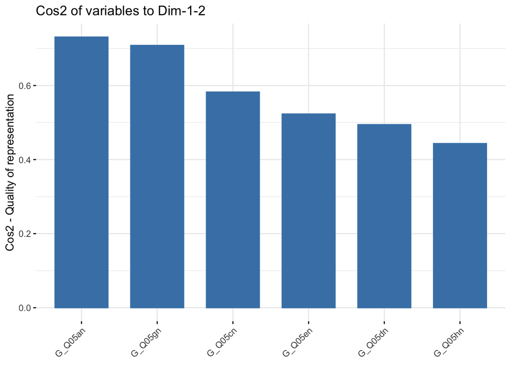

```r
#Correlation circle

#Positively correlated variables are grouped together.
#Negatively correlated variables are positioned on opposite sides of the plot origin (opposed quadrants).
#The distance between variables and the origin measures the quality of the variables on the factor map. Variables that are away from the origin are well represented on the factor map.

#Quality of representation


fviz_cos2(ICTWork1.pca, choice = "var", axes = 1:2)
```

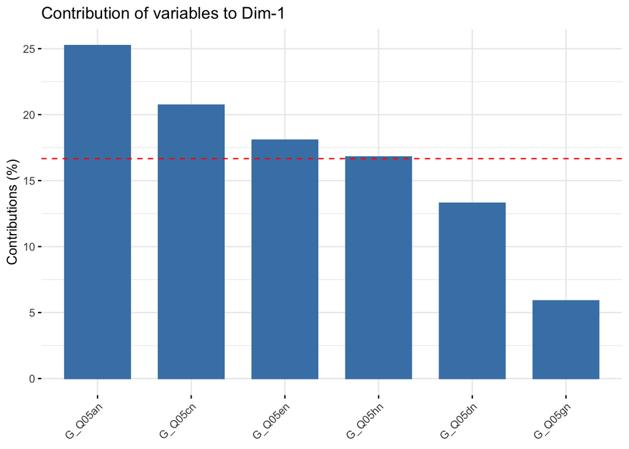

```r
#A high cos2 indicates a good representation of the variable on the principal component. In this case the variable is positioned close to the circumference of the correlation circle.

#A low cos2 indicates that the variable is not perfectly represented by the PCs. In this case the variable is close to the center of the circle.
# the better its representation on the factor map (and the more important it is to interpret these components) Variables that are closed to the center of the plot are less important for the first components.

#variables with low cos2 values will be colored in “white”
#variables with mid cos2 values will be colored in “blue”
#variables with high cos2 values will be colored in red

#Contributions of variables to Pcs

#Variables that are correlated with PC1 (i.e., Dim.1) and PC2 (i.e., Dim.2) are the most important in explaining the variability in the data set.
#Variables that do not correlated with any PC or correlated with the last dimensions are variables with low contribution and might be removed to simplify the overall analysis.

fviz_contrib(ICTWork1.pca, choice = "var", axes = 1, top = 10)
```

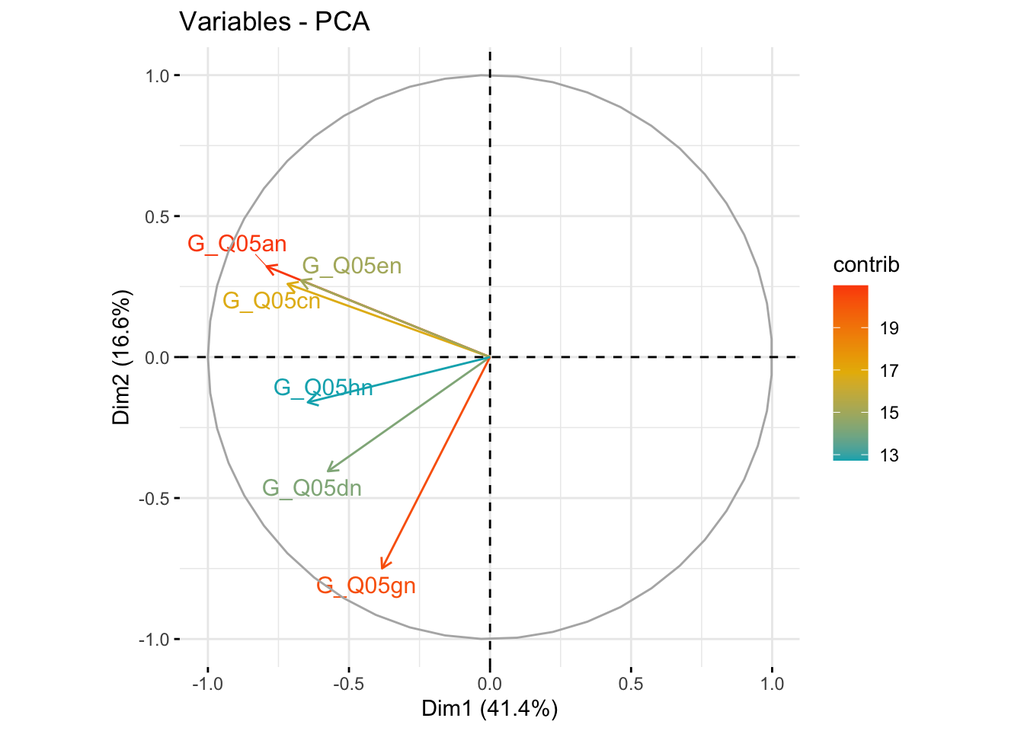

```r
fviz_pca_var(ICTWork1.pca, col.var = "contrib",
             gradient.cols = c("#00AFBB", "#E7B800", "#FC4E07"),
             repel = TRUE # Avoid text overlapping
             )
```

```r
# according to this results G_Q05dn and G_Q05gn should not be taken into account in the principal component analysis since they do not contribute much. Which can be explained because the other variables are more basic ICT akiss and G_Q05gn talks about programming language.Thus it is recommended to be leave it alone as High level ICT skill and the rest as basic thus the new Pc woult be

ICTWork2.pca <- prcomp(newMexico1ICTwork1[,c("G_Q05an", "G_Q05cn", "G_Q05en" , "G_Q05hn")], na.action=na.omit, center = TRUE,scale. = TRUE)

summary(ICTWork2.pca)
```

```
## Importance of components:
##                          PC1    PC2    PC3     PC4
## Standard deviation     1.478 0.8798 0.8019 0.63168
## Proportion of Variance 0.546 0.1935 0.1607 0.09975
## Cumulative Proportion  0.546 0.7395 0.9002 1.00000
```

```r
loadings(ICTWork2.pca)
```

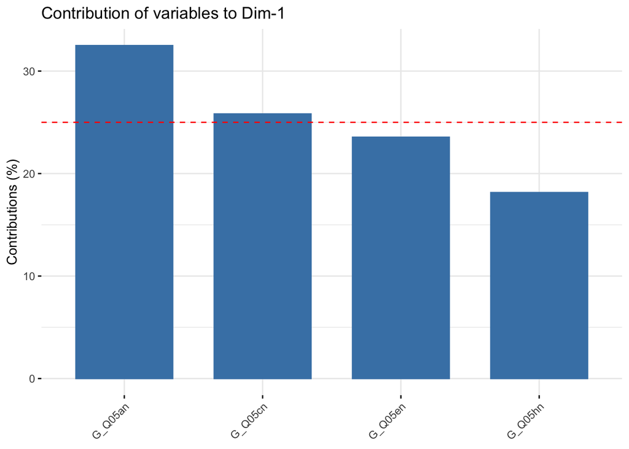

```r
fviz_contrib(ICTWork2.pca, choice = "var", axes = 1, top = 10)
```

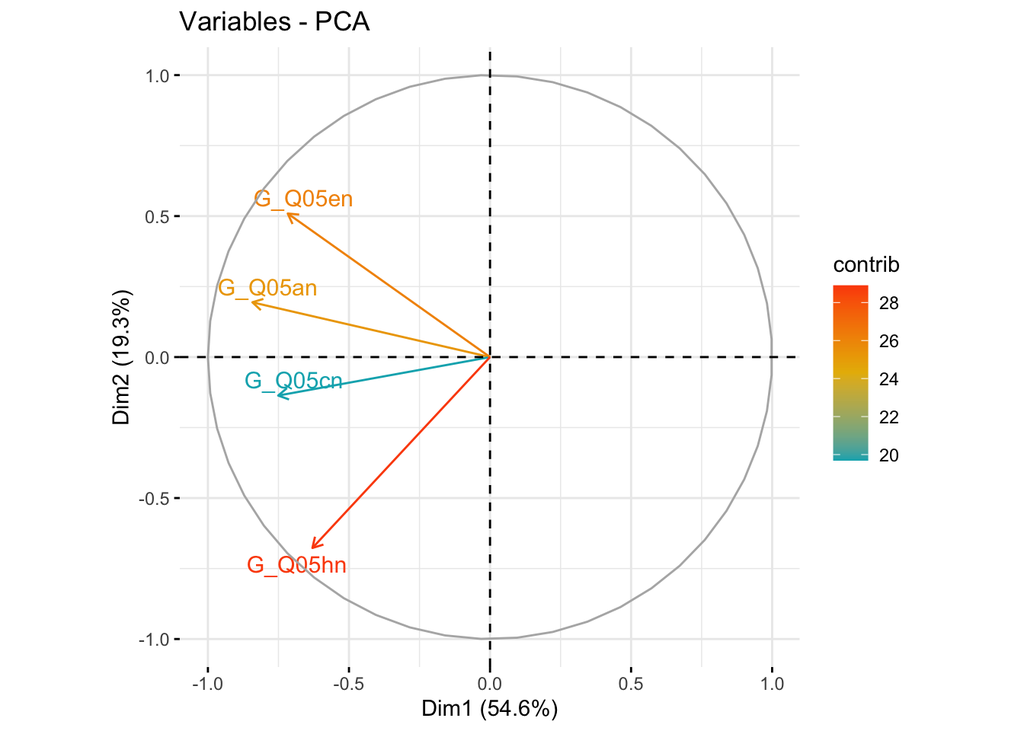

```r
fviz_pca_var(ICTWork2.pca, col.var = "contrib",
             gradient.cols = c("#00AFBB", "#E7B800", "#FC4E07"),
             repel = TRUE # Avoid text overlapping
             )
```

##Principal component analysis for work Numeracy

```r
NumeracyWork1.pca <- princomp(newMexico1ICTwork1[,c("G_Q03bn" , "G_Q03cn" , "G_Q03dn" , "G_Q03fn" , "G_Q03gn" , "G_Q03hn")], na.action=na.omit, center = TRUE,scale. = TRUE)


summary(NumeracyWork1.pca)
```

```
## Importance of components:
##                           Comp.1    Comp.2     Comp.3     Comp.4     Comp.5
## Standard deviation     2.6910239 1.8145337 1.21225453 1.13457433 1.06370827
## Proportion of Variance 0.4702608 0.2138128 0.09543139 0.08359293 0.07347654
## Cumulative Proportion  0.4702608 0.6840736 0.77950496 0.86309789 0.93657443
##                            Comp.6
## Standard deviation     0.98828085
## Proportion of Variance 0.06342557
## Cumulative Proportion  1.00000000
```

```r
loadings(NumeracyWork1.pca)
```

```
##
## Loadings:
##         Comp.1 Comp.2 Comp.3 Comp.4 Comp.5 Comp.6
## G_Q03bn  0.391  0.566  0.709         0.138
## G_Q03cn  0.528  0.257 -0.379  0.167 -0.687 -0.105
## G_Q03dn  0.409  0.260 -0.541 -0.177  0.639  0.182
## G_Q03fn  0.356 -0.486         0.755  0.247
## G_Q03gn  0.457 -0.456  0.172 -0.563        -0.486
## G_Q03hn  0.258 -0.319  0.166 -0.221 -0.196  0.847
##
##                Comp.1 Comp.2 Comp.3 Comp.4 Comp.5 Comp.6
## SS loadings     1.000  1.000  1.000  1.000  1.000  1.000
## Proportion Var  0.167  0.167  0.167  0.167  0.167  0.167
## Cumulative Var  0.167  0.333  0.500  0.667  0.833  1.000
```

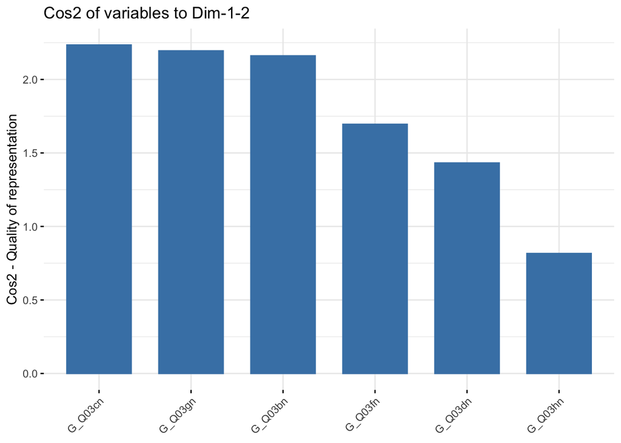

```r
#Correlation circle

#Quality of representation

fviz_cos2(NumeracyWork1.pca, choice = "var", axes = 1:2)
```

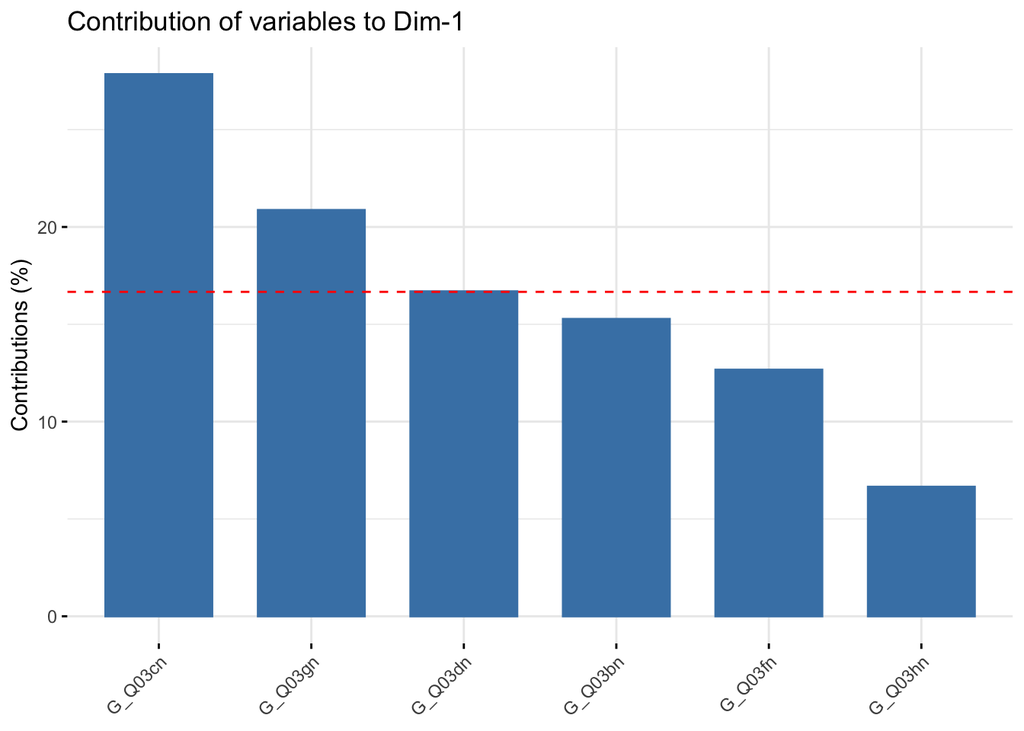

```r
#Contributions of variables to Pcs

fviz_contrib(NumeracyWork1.pca, choice = "var", axes = 1, top = 10)
```

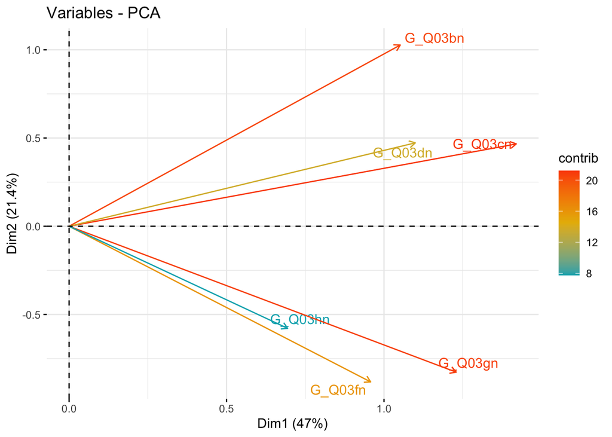

```r
#G_Q03fn (prepare charts graphs or tables), Q_q03hn (advanced math or statistics), G_Q03bn (calculating costs or budgets) below the cut off
# cn (calculate fractions or percentages), gn simple algebra or formulas, dn use a calculator are the most influential variables
fviz_pca_var(NumeracyWork1.pca, col.var = "contrib",
             gradient.cols = c("#00AFBB", "#E7B800", "#FC4E07"),
             repel = TRUE # Avoid text overlapping
             )
```

```r
# The PCA does not capture advanced numeraccy skills that are represented in the variable  Q_q03hn (advanced math or statistics), it is better to leave it independelty


NumeracyWork2.pca <- prcomp(newMexico1ICTwork1[,c("G_Q03bn" , "G_Q03cn" , "G_Q03dn" , "G_Q03fn" , "G_Q03gn")], na.action=na.omit, center = TRUE,scale. = TRUE)

NumeracyWork2.pca$scale
```

```
##  G_Q03bn  G_Q03cn  G_Q03dn  G_Q03fn  G_Q03gn
## 1.711837 1.740762 1.548823 1.583674 1.697291
```

```r
summary(NumeracyWork2.pca)
```

```
## Importance of components:
##                          PC1    PC2    PC3     PC4     PC5
## Standard deviation     1.573 1.0549 0.7351 0.68282 0.63682
## Proportion of Variance 0.495 0.2225 0.1081 0.09325 0.08111
## Cumulative Proportion  0.495 0.7176 0.8256 0.91889 1.00000
```

```r
NumeracyWork3.pca <- princomp(newMexico1ICTwork1[,c("G_Q03bn" , "G_Q03cn" , "G_Q03dn" , "G_Q03fn" , "G_Q03gn")], na.action=na.omit, center = TRUE,cor = TRUE)

NumeracyWork3.pca$scale
```

```
##  G_Q03bn  G_Q03cn  G_Q03dn  G_Q03fn  G_Q03gn
## 1.711043 1.739955 1.548106 1.582940 1.696504
```

```r
loadings(NumeracyWork3.pca)
```

```
##
## Loadings:
##         Comp.1 Comp.2 Comp.3 Comp.4 Comp.5
## G_Q03bn  0.404  0.521  0.692         0.291
## G_Q03cn  0.522  0.196 -0.103 -0.155 -0.809
## G_Q03dn  0.481  0.271 -0.681         0.476
## G_Q03fn  0.375 -0.621  0.209 -0.629  0.185
## G_Q03gn  0.437 -0.481         0.758
##
##                Comp.1 Comp.2 Comp.3 Comp.4 Comp.5
## SS loadings       1.0    1.0    1.0    1.0    1.0
## Proportion Var    0.2    0.2    0.2    0.2    0.2
## Cumulative Var    0.2    0.4    0.6    0.8    1.0
```

```r
summary(NumeracyWork3.pca)
```

```
## Importance of components:
##                           Comp.1    Comp.2    Comp.3     Comp.4     Comp.5
## Standard deviation     1.5732534 1.0548663 0.7350811 0.68282342 0.63681929
## Proportion of Variance 0.4950252 0.2225486 0.1080689 0.09324956 0.08110776
## Cumulative Proportion  0.4950252 0.7175738 0.8256427 0.91889224 1.00000000
```

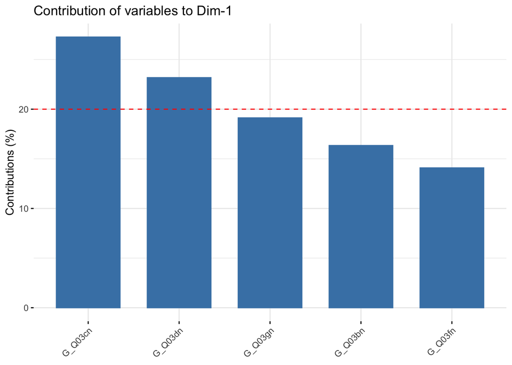

```r
fviz_contrib(NumeracyWork2.pca, choice = "var", axes = 1, top = 10)
```

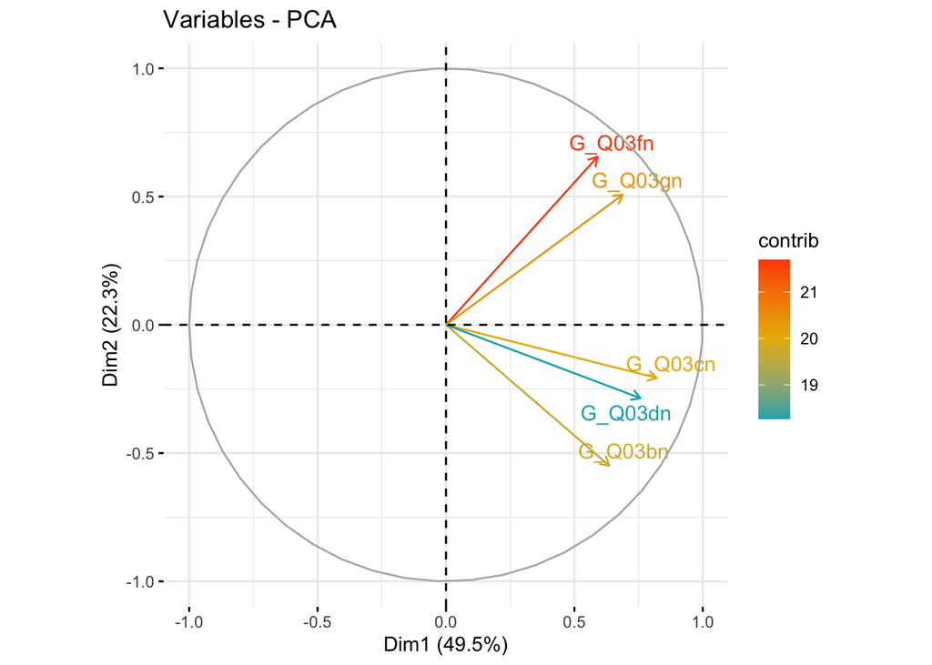

```r
fviz_pca_var(NumeracyWork2.pca, col.var = "contrib",
             gradient.cols = c("#00AFBB", "#E7B800", "#FC4E07"),
             repel = TRUE # Avoid text overlapping
             )
```

##Principal component analysis for work Literacy

```r
LiteracyWork1.pca <- prcomp(newMexico1ICTwork1[,c("G_Q01an" , "G_Q02an" , "G_Q02bn" , "G_Q02cn" , "G_Q02dn")], na.action=na.omit, center = TRUE,scale. = TRUE)


summary(LiteracyWork1.pca)
```

```
## Importance of components:
##                           PC1    PC2    PC3    PC4     PC5
## Standard deviation     1.4752 0.9760 0.8709 0.8111 0.67449
## Proportion of Variance 0.4352 0.1905 0.1517 0.1316 0.09099
## Cumulative Proportion  0.4352 0.6257 0.7774 0.9090 1.00000
```

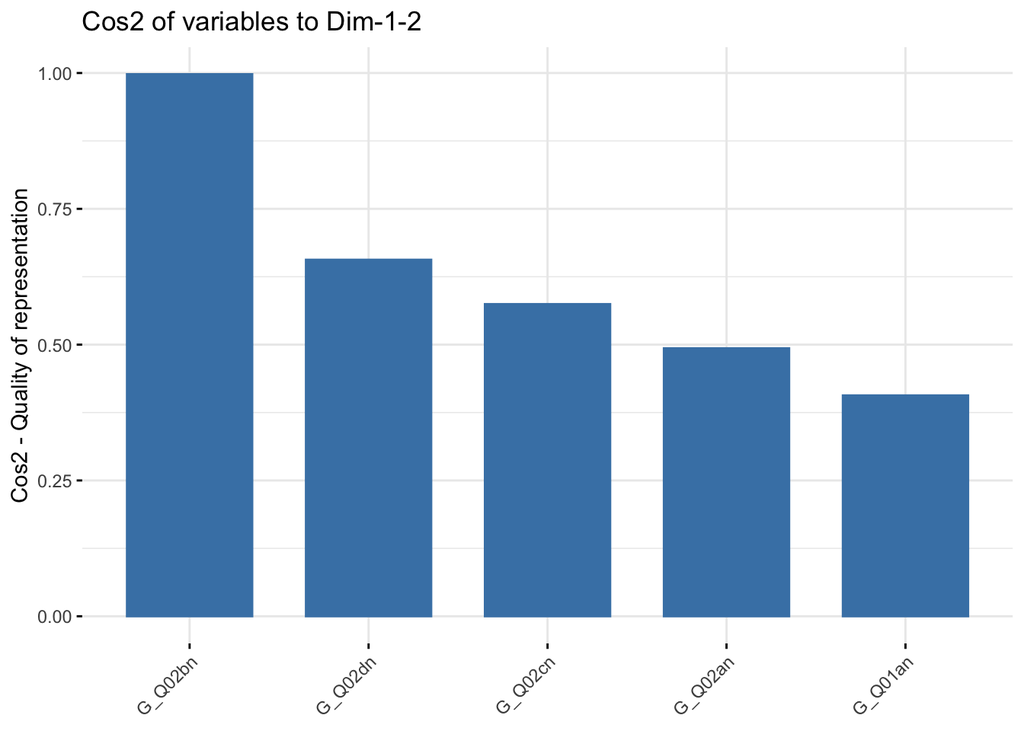

```r
#Correlation circle

#Quality of representation

fviz_cos2(LiteracyWork1.pca, choice = "var", axes = 1:2)
```

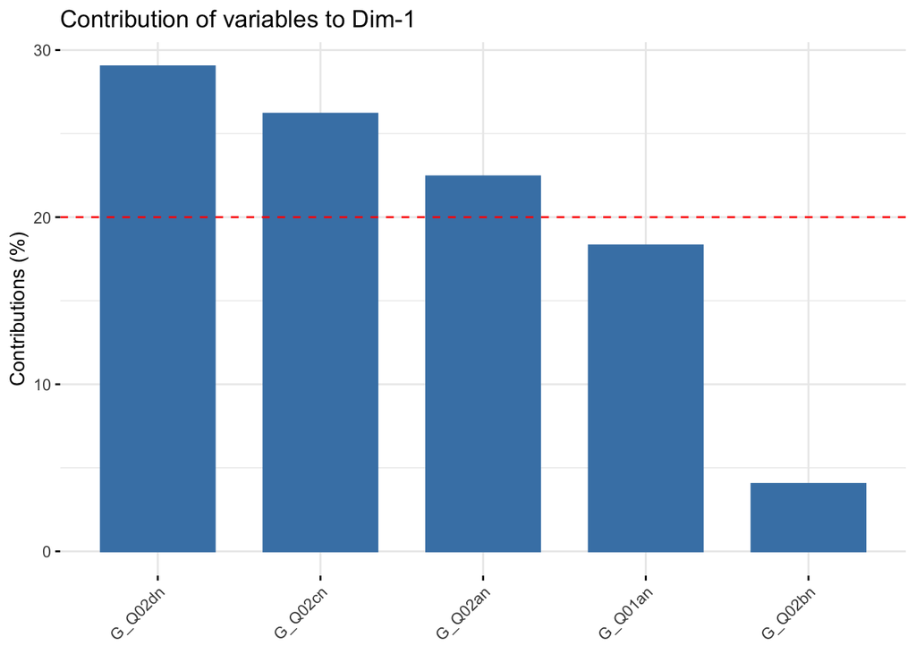

```r
#Contributions of variables to Pcs

fviz_contrib(LiteracyWork1.pca, choice = "var", axes = 1, top = 10)
```

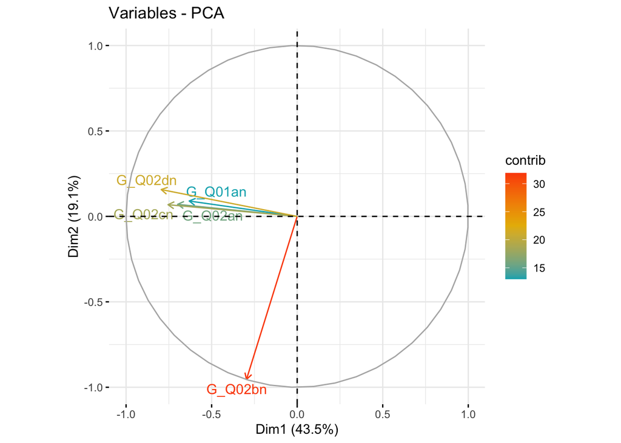

```r
#G_Q01a (read directions and instructions), Q_q02b (write articles),  below the cut off
# G_q02dn (fill in forms), G_Q02cn (write reports), Q_q02an (write letter memos and mails) are the most influential variables
fviz_pca_var(LiteracyWork1.pca, col.var = "contrib",
             gradient.cols = c("#00AFBB", "#E7B800", "#FC4E07"),
             repel = TRUE # Avoid text overlapping
             )
```

```r
# The PCA does not capture advanced numeraccy skills that are represented in the variable  Q_q02bn (write articles)), it is better to leave it independelty, take a look at the graph in one it say that bis the one tha contributes the most but in the bars it is far below from the cut off

LiteracyWork2.pca <- prcomp(newMexico1ICTwork1[,c("G_Q01an" , "G_Q02an" , "G_Q02cn" , "G_Q02dn")], na.action=na.omit, center = TRUE,scale. = TRUE)


summary(LiteracyWork2.pca)
```

```
## Importance of components:
##                           PC1    PC2    PC3    PC4
## Standard deviation     1.4583 0.8709 0.8113 0.6757
## Proportion of Variance 0.5317 0.1896 0.1646 0.1141
## Cumulative Proportion  0.5317 0.7213 0.8859 1.0000
```

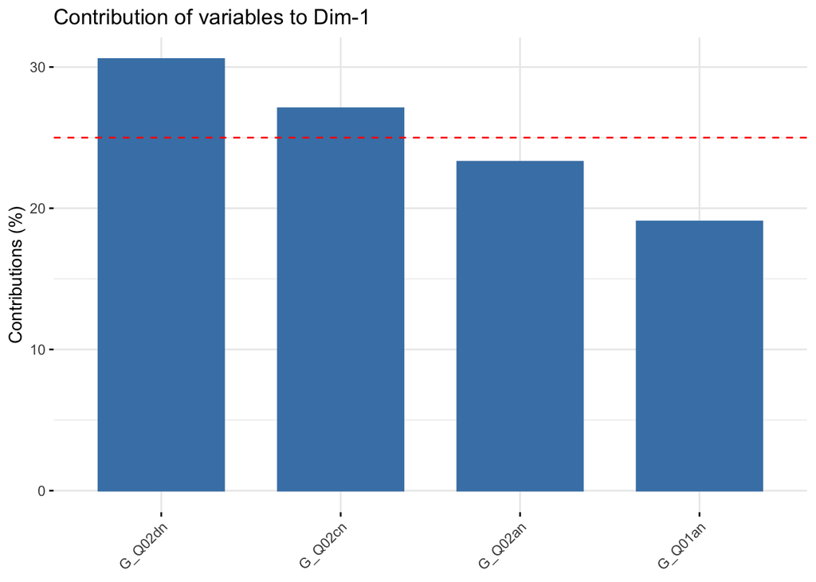

```r
fviz_contrib(LiteracyWork2.pca, choice = "var",
             gradient.cols = c("#00AFBB", "#E7B800", "#FC4E07"),
             axes = 1, top = 10)
```

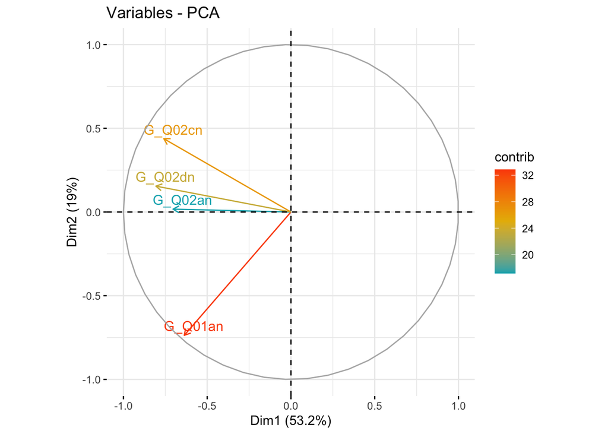

```r
fviz_pca_var(LiteracyWork2.pca, col.var = "contrib",
             gradient.cols = c("#00AFBB", "#E7B800", "#FC4E07"),
             repel = TRUE # Avoid text overlapping
             )
```

```r
 #soft skills


#Correlation circle

#Quality of representation


# The PCA does not capture advanced numeraccy skills that are represented in the variable  Q_q02bn (write articles)), it is better to leave it independelty, take a look at the graph in one it say that bis the one tha contributes the most but in the bars it is far below from the cut off
```

```r
Skillsreg <- lm(YEARLYINCPR ~ AGE_R + GENDER_Rn + B_Q01an+ G_Q05gn + G_Q05an + G_Q05en + G_Q03hn + G_Q03cn + G_Q02bn + G_Q02dn + F_Q02dn,  newMexico1ICTwork1)

summary(Skillsreg)
```

```
##
## Call:
## lm(formula = YEARLYINCPR ~ AGE_R + GENDER_Rn + B_Q01an + G_Q05gn +
##     G_Q05an + G_Q05en + G_Q03hn + G_Q03cn + G_Q02bn + G_Q02dn +
##     F_Q02dn, data = newMexico1ICTwork1)
##
## Residuals:
##     Min      1Q  Median      3Q     Max
## -4.3322 -0.7363  0.3188  0.9264  3.6323
##
## Coefficients:
##              Estimate Std. Error t value Pr(>|t|)
## (Intercept)  2.344618   0.253780   9.239  < 2e-16 ***
## AGE_R        0.015049   0.004246   3.544 0.000415 ***
## GENDER_Rn   -0.386720   0.093947  -4.116 4.22e-05 ***
## B_Q01an      0.086857   0.014342   6.056 2.08e-09 ***
## G_Q05gn      0.028748   0.036511   0.787 0.431280
## G_Q05an      0.064954   0.038380   1.692 0.090930 .
## G_Q05en      0.137659   0.032840   4.192 3.05e-05 ***
## G_Q03hn     -0.012347   0.037736  -0.327 0.743592
## G_Q03cn     -0.010579   0.029465  -0.359 0.719647
## G_Q02bn     -0.032005   0.050008  -0.640 0.522352
## G_Q02dn      0.178415   0.031928   5.588 3.08e-08 ***
## F_Q02dn     -0.136619   0.025594  -5.338 1.20e-07 ***
## ---
## Signif. codes:  0 '***' 0.001 '**' 0.01 '*' 0.05 '.' 0.1 ' ' 1
##
## Residual standard error: 1.358 on 862 degrees of freedom
##   (205 observations deleted due to missingness)
## Multiple R-squared:  0.2453, Adjusted R-squared:  0.2357
## F-statistic: 25.47 on 11 and 862 DF,  p-value: < 2.2e-16
```